# Non - Randomized controlled trials (NRCTs)

## 3.2 ITS no controlado, dos intervenciones

Algunos diseños pueden incluir múltiples intervenciones y es bastante sencillo ampliar el modelo para tener en cuenta este tipo de cosas Haremos un nuevo conjunto de datos que incluya una segunda intervención y una tendencia post-intervención-2.

```r
# create a dummy dataframe
# Here the interruption takes place at week 51
df3<-tibble::tibble(
  Time = 1:150,
  Intervention = c(rep(0,50),rep(1,100)),
  Post.intervention.time = c(rep(0,50),1:100),
  Intervention.2 = c(rep(0,100),rep(1,50)),
  Post.intervention.2.time = c(rep(0,100),1:50),
  quantity.x = c(sort(sample(2000:2500,size = 50,replace = T),decreasing = T)+sample(-20:20,50,replace = T),c(sort(sample(200:1700,size = 50,replace = T),decreasing = T)+sample(-40:40,50,replace = T)),c(sort(sample(200:450,size = 50,replace = T),decreasing = F)+sample(-40:40,50,replace = T)))
)
```

|  | Time | Intervention | Post.intervention.time | Intervention.2 | Post.intervention.2.time | quantity.x |
| --- | --- | --- | --- | --- | --- | --- |
| 1 | 1 | 0 | 0 | 0 | 0 | 2493 |
| 2 | 2 | 0 | 0 | 0 | 0 | 2479 |
| 3 | 3 | 0 | 0 | 0 | 0 | 2487 |
| 4 | 4 | 0 | 0 | 0 | 0 | 2433 |
| 5 | 5 | 0 | 0 | 0 | 0 | 2443 |
| 6 | 6 | 0 | 0 | 0 | 0 | 2440 |
| 7 | 7 | 0 | 0 | 0 | 0 | 2428 |
| 8 | 8 | 0 | 0 | 0 | 0 | 2410 |
| 9 | 9 | 0 | 0 | 0 | 0 | 2401 |
| 10 | 10 | 0 | 0 | 0 | 0 | 2369 |

[output cut: 140 more lines]

El nuevo modelo ITS tiene el siguiente aspecto

gls(quantity.x ~ Time + Intervention + Post.intervention.time + Intervention.2 + Post.intervention.2.time, data = df,method=“ML”, correlation= corARMA(p=2,q=2, form = ~ Time))

Recuerde que probablemente debería tratar la autocorrelación en este punto. El método es el mismo que antes, así que no lo reproduciré aquí. Sólo voy a inventar algunos valores para p y q

```r
model.d = gls(quantity.x ~ Time + Intervention + Post.intervention.time +
                Intervention.2 + Post.intervention.2.time,
              data = df3,method="ML",
              correlation= corARMA(p=2,q=2, form = ~ Time))

# Show a summary of the model
summary(model.d)
```

```
## Generalized least squares fit by maximum likelihood
##   Model: quantity.x ~ Time + Intervention + Post.intervention.time + Intervention.2 +      Post.intervention.2.time
##   Data: df3
##        AIC    BIC    logLik
##   1465.283 1498.4 -721.6415
##
## Correlation Structure: ARMA(2,2)
##  Formula: ~Time
##  Parameter estimate(s):
##       Phi1       Phi2     Theta1     Theta2
##  0.2987964  0.5678155  0.2943403 -0.1548314
##
## Coefficients:
##                              Value Std.Error  t-value p-value
## (Intercept)              2470.8978  48.91860 50.51039  0.0000
## Time                       -8.6418   1.44766 -5.96952  0.0000
## Intervention             -265.9193  28.90222 -9.20065  0.0000
## Post.intervention.time    -23.1480   2.41652 -9.57909  0.0000
## Intervention.2             42.5942  28.91517  1.47307  0.1429
## Post.intervention.2.time   35.9351   2.41652 14.87061  0.0000
##
##  Correlation:
##                          (Intr) Time   Intrvn Pst.n. Intr.2
## Time                     -0.796
## Intervention              0.067 -0.222
## Post.intervention.time    0.541 -0.857 -0.036
## Intervention.2           -0.008  0.033  0.032 -0.148
## Post.intervention.2.time -0.072  0.290  0.204 -0.660 -0.047
##
## Standardized residuals:
##        Min         Q1        Med         Q3        Max
## -2.0243716 -0.7181474 -0.2269478  0.3174946  3.1180126
##
## Residual standard error: 54.84668
## Degrees of freedom: 150 total; 144 residual
```

Si volvemos al ejemplo anterior, más sencillo, probablemente veamos que estos coeficientes son fáciles de explicar.

- El intercepto sigue siendo el valor medio inicial de la cantidad.x
- El tiempo es la pendiente previa a la intervención
- La intervención describe el cambio de paso que se produce en el punto temporal de la intervención
- Tiempo.post.intervención describe el cambio de pendiente adicional que se produce en el punto de tiempo de la intervención
- Intervención.2 describe el cambio de paso que se produce en el punto temporal de la segunda intervención
- Tiempo.post.intervención.2 describe el cambio de pendiente adicional que se produce en el momento de la segunda intervención.

Tomemos los valores modelizados estimados para el nuevo estudio de dos intervenciones

```r
df3<-df3 %>% mutate(
  model.d.predictions = predictSE.gls (model.d, df3, se.fit=T)$fit,
  model.d.se = predictSE.gls (model.d, df3, se.fit=T)$se
  )
```

|  | Time | Intervention | Post.intervention.time | Intervention.2 | Post.intervention.2.time | quantity.x | model.d.predictions | model.d.se |
| --- | --- | --- | --- | --- | --- | --- | --- | --- |
| 1 | 1 | 0 | 0 | 0 | 0 | 2493 | 2462.255941828663 | 47.77468121812137 |
| 2 | 2 | 0 | 0 | 0 | 0 | 2479 | 2453.614097048955 | 46.64763950638403 |
| 3 | 3 | 0 | 0 | 0 | 0 | 2487 | 2444.972252269246 | 45.53872889720614 |
| 4 | 4 | 0 | 0 | 0 | 0 | 2433 | 2436.330407489538 | 44.44930640246425 |
| 5 | 5 | 0 | 0 | 0 | 0 | 2443 | 2427.688562709829 | 43.38084026132154 |
| 6 | 6 | 0 | 0 | 0 | 0 | 2440 | 2419.046717930121 | 42.3349172188594 |
| 7 | 7 | 0 | 0 | 0 | 0 | 2428 | 2410.404873150412 | 41.31324947408876 |
| 8 | 8 | 0 | 0 | 0 | 0 | 2410 | 2401.763028370704 | 40.31768098886823 |
| 9 | 9 | 0 | 0 | 0 | 0 | 2401 | 2393.121183590995 | 39.3501927639908 |
| 10 | 10 | 0 | 0 | 0 | 0 | 2369 | 2384.479338811287 | 38.41290659189377 |

[output cut: 140 more lines]

Hagamos un dibujo en el que se muestren los puntos de datos brutos y, a continuación, añadamos los datos modelizados como una línea que describa las observaciones objetivas y una cinta que muestre el intervalo de confianza del 95% sobre el modelo

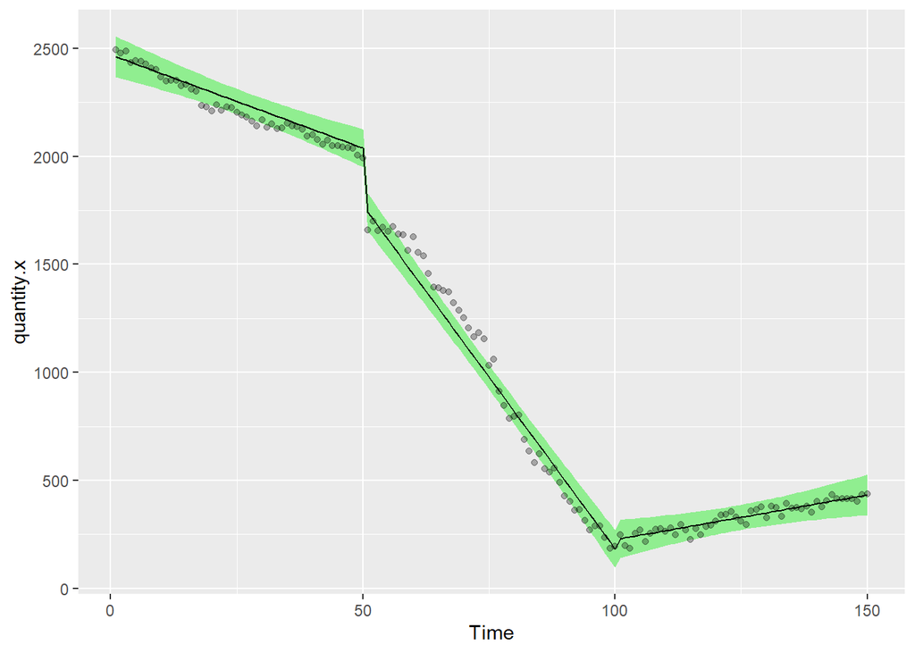

```r
 ggplot(df3,aes(Time,quantity.x))+
  geom_ribbon(aes(ymin = model.d.predictions - (1.96*model.d.se), ymax = model.d.predictions + (1.96*model.d.se)), fill = "lightgreen")+
  geom_line(aes(Time,model.d.predictions),color="black",lty=1)+
  geom_point(alpha=0.3)
```

calculemos el primer contrafactual, que no hubo intervenciones

```r
df4<-filter(df3,Time<51)
model.e = gls(quantity.x ~ Time, data = df4, correlation= corARMA(p=1, q=1, form = ~ Time),method="ML")

df3<-df3 %>% mutate(
  model.e.predictions = predictSE.gls (model.e, newdata = df3, se.fit=T)$fit,
  model.e.se = predictSE.gls (model.e, df3, se.fit=T)$se
)
```

y luego el segundo contrafactual, que sólo ocurrió la primera intervención

```r
df5<-filter(df3,Time<101)
model.f = gls(quantity.x ~ Time + Intervention + Post.intervention.time, data = df5, correlation= corARMA(p=1, q=1, form = ~ Time),method="ML")

df3<-df3 %>% mutate(
  model.f.predictions = predictSE.gls (model.f, newdata = df3, se.fit=T)$fit,
  model.f.se = predictSE.gls (model.f, df3, se.fit=T)$se
)
```

Por último, vamos a dibujar el gráfico que muestra los datos reales (negro, verde), el primero (rojo, rosa) y el segundo (azul marino, turquesa) contrafactuales

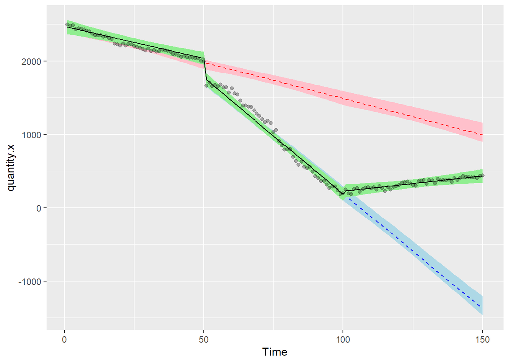

```r
ggplot(df3,aes(Time,quantity.x))+
  geom_ribbon(aes(ymin = model.f.predictions - (1.96*model.d.se), ymax = model.f.predictions + (1.96*model.e.se)), fill = "lightblue")+
  geom_line(aes(Time,model.f.predictions),color="blue",lty=2)+
  geom_ribbon(aes(ymin = model.e.predictions - (1.96*model.d.se), ymax = model.e.predictions + (1.96*model.e.se)), fill = "pink")+
  geom_line(aes(Time,model.e.predictions),color="red",lty=2)+
  geom_ribbon(aes(ymin = model.d.predictions - (1.96*model.d.se), ymax = model.d.predictions + (1.96*model.d.se)), fill = "lightgreen")+
  geom_line(aes(Time,model.d.predictions),color="black",lty=1)+
  geom_point(alpha=0.3)
```

Puedes utilizar los valores modelizados almacenados para hacer los cálculos que quieras con respecto a las diferencias relativas. Recuerde que algunas cosas nunca pueden ser inferiores a cero y que su hipótesis probablemente no sea que existe una tendencia lineal que continúa para siempre. En este contexto, piense detenidamente en sus contrafactuales.

## 3.3 ITS controlado, una intervención

Cuando se trata de series temporales, el STI controlado es lo mejor que se puede hacer. El control permite calibrar el STI para tener en cuenta los cambios seculares y periódicos independientes. Supongamos que la cantidad.x y la cantidad.y están relacionadas. Ambas han mostrado algún tipo de cambio secular de largo alcance (por ejemplo, está la tendencia previa a la intervención en los ejemplos anteriores). Digamos que tanto la cantidad.x como la cantidad.y experimentan una tendencia paralela antes de la intervención.

Se pretende que la intervención afecte al cambio en la cantidad.x, pero no en la cantidad.y, por lo que las tendencias posteriores a la intervención en la cantidad.y pueden tenerse en cuenta en nuestro modelo, reforzando nuestros resultados.

Hagamos un conjunto de datos.

```r
# create a dummy dataframe
# Here the interruption takes place at week 51
df.x<-tibble::tibble(
  x = 1,
  Time = 1:100,
  x.Time = x*Time,
  Intervention = c(rep(0,50),rep(1,50)),
  x.Intervention = x*Intervention,
  Post.intervention.time = c(rep(0,50),1:50),
  x.Post.intervention.time = x * Post.intervention.time,
  quantity.x = c(sort(sample(200:300,size = 50,replace = T),decreasing = T)+sample(-20:20,50,replace = T),c(sort(sample(20:170,size = 50,replace = T),decreasing = T)+sample(-40:40,50,replace = T)))
)

df.y<-tibble::tibble(
  x = 0,
  Time = 1:100,
  x.Time = x*Time,
  Intervention = c(rep(0,50),rep(1,50)),
  x.Intervention = x*Intervention,
  Post.intervention.time = c(rep(0,50),1:50),
  x.Post.intervention.time = x * Post.intervention.time,
  quantity.x = c(sort(sample(500:600,size = 50,replace = T),decreasing = T)+sample(-20:20,50,replace = T),c(sort(sample(280:500,size = 50,replace = T),decreasing = T)+sample(-40:40,50,replace = T)))
)

df6 = bind_rows(df.x,df.y) %>%
  arrange(Time,x)
```

|  | x | Time | x.Time | Intervention | x.Intervention | Post.intervention.time | x.Post.intervention.time | quantity.x |
| --- | --- | --- | --- | --- | --- | --- | --- | --- |
| 1 | 0 | 1 | 0 | 0 | 0 | 0 | 0 | 605 |
| 2 | 1 | 1 | 1 | 0 | 0 | 0 | 0 | 317 |
| 3 | 0 | 2 | 0 | 0 | 0 | 0 | 0 | 597 |
| 4 | 1 | 2 | 2 | 0 | 0 | 0 | 0 | 288 |
| 5 | 0 | 3 | 0 | 0 | 0 | 0 | 0 | 604 |
| 6 | 1 | 3 | 3 | 0 | 0 | 0 | 0 | 315 |
| 7 | 0 | 4 | 0 | 0 | 0 | 0 | 0 | 606 |
| 8 | 1 | 4 | 4 | 0 | 0 | 0 | 0 | 315 |
| 9 | 0 | 5 | 0 | 0 | 0 | 0 | 0 | 589 |
| 10 | 1 | 5 | 5 | 0 | 0 | 0 | 0 | 281 |

[output cut: 190 more lines]

Observe detenidamente el conjunto de datos. He introducido la variable x (que diferencia entre los grupos de control (0) y de prueba (1), además de algunos términos de interacción nuevos, como x.Tiempo, x.Intervención y x.Tiempo.post.intervención. Cada uno de ellos no es más que el valor de la variable multiplicado por x (que indica las variables de control [0, es decir, cantidad.y] o las variables de interés [1, es decir, cantidad.x]). Esto hace que esas variables sean nulas para los controles y que los cambios de paso o tendencia sean significativos para las líneas de los datos relativos a la cantidad.x

El modelo ITS es ahora un poco más complicado. De nuevo, me he saltado el paso en el que probamos diferentes valores de p y q. ¡No debería saltárselo!

gls(quantity.x ~ Time + x.Time + Intervention + x.Intervention + Post.intervention.time + x.Post.intervention.time, data = df6, correlation= corARMA(p=1, q=1, form = ~ Time|x),method=“ML”)

Nótese que hemos tenido que cambiar el argumento form = ~ Time|x) en el corARMA para tener en cuenta el hecho de que necesita corregir la autocorrelación a través del tiempo y a través de los dos grupos donde x == 1 y x == 0

```r
model.g = gls(quantity.x ~ x + Time + x.Time + Intervention + x.Intervention +
                Post.intervention.time + x.Post.intervention.time,
              data = df6,method="ML",
              correlation= corARMA(p=2,q=2, form = ~ Time|x))

# Show a summary of the model
summary(model.g)
```

```
## Generalized least squares fit by maximum likelihood
##   Model: quantity.x ~ x + Time + x.Time + Intervention + x.Intervention +      Post.intervention.time + x.Post.intervention.time
##   Data: df6
##        AIC      BIC    logLik
##   1760.661 1803.539 -867.3304
##
## Correlation Structure: ARMA(2,2)
##  Formula: ~Time | x
##  Parameter estimate(s):
##        Phi1        Phi2      Theta1      Theta2
## -0.11217173  0.80387478 -0.02526763 -0.97471230
##
## Coefficients:
##                              Value Std.Error   t-value p-value
## (Intercept)               604.0888  2.886986 209.24550  0.0000
## x                        -302.5782  4.082815 -74.11020  0.0000
## Time                       -2.0963  0.106651 -19.65578  0.0000
## x.Time                      0.2096  0.150827   1.38941  0.1663
## Intervention                1.9850  4.797868   0.41373  0.6795
## x.Intervention            -35.9907  6.785210  -5.30428  0.0000
## Post.intervention.time     -1.8272  0.126398 -14.45600  0.0000
## x.Post.intervention.time    0.8279  0.178754   4.63142  0.0000
##
##  Correlation:
##                          (Intr) x      Time   x.Time Intrvn x.Intr Pst.n.
## x                        -0.707
## Time                     -0.958  0.677
## x.Time                    0.677 -0.958 -0.707
## Intervention              0.601 -0.425 -0.764  0.541
## x.Intervention           -0.425  0.601  0.541 -0.764 -0.707
## Post.intervention.time    0.656 -0.464 -0.593  0.419 -0.013  0.009
## x.Post.intervention.time -0.464  0.656  0.419 -0.593  0.009 -0.013 -0.707
##
## Standardized residuals:
##        Min         Q1        Med         Q3        Max
## -2.3976890 -0.6350861 -0.1071354  0.7216605  2.3090727
##
## Residual standard error: 19.08084
## Degrees of freedom: 200 total; 192 residual
```

Si te vuelves más **sofisticado** en estas cosas, también podrías utilizar términos de interacción en tu modelo para conseguir el mismo resultado

```r
model.h = gls(quantity.x ~ Time*x + Intervention*x + Post.intervention.time*x, data = df6,method="ML", correlation= corARMA(p=2,q=2, form = ~ Time|x))

# Show a summary of the model
summary(model.h)
```

```
## Generalized least squares fit by maximum likelihood
##   Model: quantity.x ~ Time * x + Intervention * x + Post.intervention.time *      x
##   Data: df6
##        AIC      BIC    logLik
##   1760.661 1803.539 -867.3304
##
## Correlation Structure: ARMA(2,2)
##  Formula: ~Time | x
##  Parameter estimate(s):
##        Phi1        Phi2      Theta1      Theta2
## -0.11217173  0.80387478 -0.02526763 -0.97471230
##
## Coefficients:
##                              Value Std.Error   t-value p-value
## (Intercept)               604.0888  2.886986 209.24550  0.0000
## Time                       -2.0963  0.106651 -19.65578  0.0000
## x                        -302.5782  4.082815 -74.11020  0.0000
## Intervention                1.9850  4.797868   0.41373  0.6795
## Post.intervention.time     -1.8272  0.126398 -14.45600  0.0000
## Time:x                      0.2096  0.150827   1.38941  0.1663
## x:Intervention            -35.9907  6.785210  -5.30428  0.0000
## x:Post.intervention.time    0.8279  0.178754   4.63142  0.0000
##
##  Correlation:
##                          (Intr) Time   x      Intrvn Pst.n. Time:x x:Intr
## Time                     -0.958
## x                        -0.707  0.677
## Intervention              0.601 -0.764 -0.425
## Post.intervention.time    0.656 -0.593 -0.464 -0.013
## Time:x                    0.677 -0.707 -0.958  0.541  0.419
## x:Intervention           -0.425  0.541  0.601 -0.707  0.009 -0.764
## x:Post.intervention.time -0.464  0.419  0.656  0.009 -0.707 -0.593 -0.013
##
## Standardized residuals:
##        Min         Q1        Med         Q3        Max
## -2.3976890 -0.6350861 -0.1071354  0.7216605  2.3090727
##
## Residual standard error: 19.08084
## Degrees of freedom: 200 total; 192 residual
```

¿Ve? ¡Son idénticos! Personalmente prefiero tener las variables como x.Intervention escritas en mis conjuntos de datos en su totalidad. Trabajar con interacciones me confunde y tampoco me gusta la forma en que R presenta los coeficientes fuera de orden.

Así que veamos en detalle la versión corta

```r
coefficients(model.g)
```

```
##              (Intercept)                        x                     Time
##              604.0888189             -302.5782150               -2.0963091
##                   x.Time             Intervention           x.Intervention
##                0.2095609                1.9850321              -35.9906518
##   Post.intervention.time x.Post.intervention.time
##               -1.8272114                0.8278852
```

La interpretación es la siguiente

- Intercepto es el valor medio del grupo de control al inicio del estudio
- x es la diferencia entre Intercepto y el valor de la cantidad.x al inicio del estudio. Cuando dibujemos el gráfico a continuación, verá que la línea para la cantidad.x comienza en 302.6 unidades en la semana 1.
- Tiempo es la pendiente previa a la intervención para el grupo de control
- x.Tiempo es la diferencia entre Tiempo y los valores de cantidad.x (¡vea cómo influye el grupo de control en nuestros resultados!)
- Intervención describe el cambio de paso que se produce en el punto temporal de intervención en el grupo de control
- x.Intervención describe la diferencia en los cambios de paso que se produce en el punto de tiempo de intervención entre los dos grupos
- El tiempo posterior a la intervención describe el cambio de pendiente que se produce en el punto temporal de la intervención en el grupo de control
- x.Tiempo.post.intervención describe la diferencia en los cambios de pendiente que se produce en el punto temporal de la intervención en el grupo de control.

Tomemos los valores modelizados estimados para el nuevo estudio de intervención controlada

```r
df6<-df6 %>% mutate(
  model.g.predictions = predictSE.gls (model.g, df6, se.fit=T)$fit,
  model.g.se = predictSE.gls (model.g, df6, se.fit=T)$se
  )
```

A continuación, dibuje un cuadro en el que se muestren los puntos de datos brutos y añada los datos modelizados como una línea que describa las observaciones objetivas y una cinta que muestre el intervalo de confianza del 95% en el modelo.

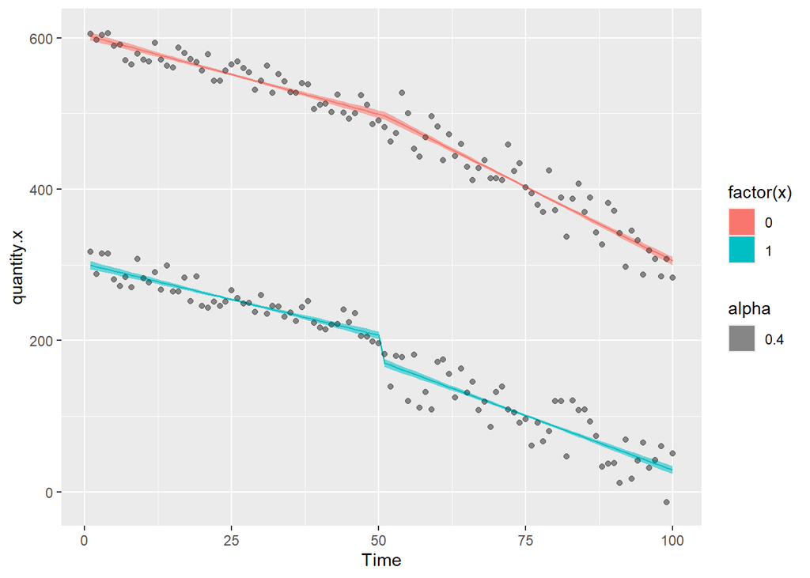

```r
ggplot(df6,aes(Time,quantity.x))+geom_point(color="grey")+
  geom_ribbon(aes(ymin = model.g.predictions - (1.96*model.g.se), ymax = model.g.predictions + (1.96*model.g.se),fill=factor(x),alpha=0.4))+
  geom_line(aes(Time,model.g.predictions,color=factor(x)),lty=1)+
  geom_point(alpha=0.3)
```

Así pues, calculemos los contrafactuales para cada uno de ellos y añadamos las predicciones al conjunto de datos

```r
df7<-filter(df6,Time<51)
model.i = gls(quantity.x ~ x + Time + x.Time, data = df7, correlation= corARMA(p=1, q=1, form = ~ Time|x),method="ML")

df6<-df6 %>% mutate(
  model.i.predictions = predictSE.gls (model.i, newdata = df6, se.fit=T)$fit,
  model.i.se = predictSE.gls (model.i, df6, se.fit=T)$se
)
```

A continuación, trace los resultados

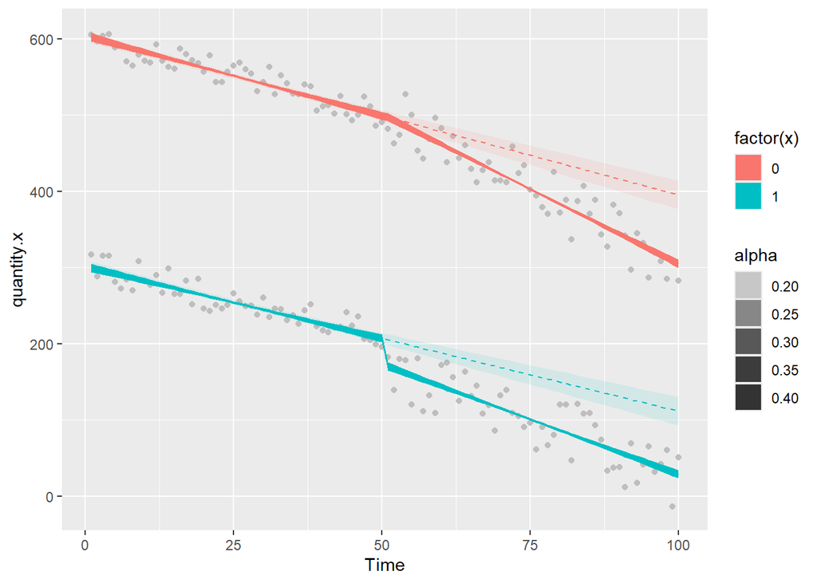

```r
 ggplot(df6,aes(Time,quantity.x))+geom_point(color="grey")+
  geom_ribbon(aes(ymin = model.g.predictions - (1.96*model.g.se), ymax = model.g.predictions + (1.96*model.g.se),fill=factor(x),alpha=0.4))+
  geom_line(aes(Time,model.g.predictions,color=factor(x)),lty=1)+
  geom_line(aes(Time,model.i.predictions,color=factor(x)),lty=2)+
  geom_ribbon(aes(ymin = model.i.predictions - (1.96*model.i.se), ymax = model.i.predictions + (1.96*model.i.se),fill=factor(x),alpha=0.2))
```

Podemos ver que en el grupo de interés, ha habido un gran cambio en la cantidad.x desde la intervención, pero también ha habido un gran cambio en la cantidad.y el grupo de control. ¿El efecto que estamos viendo en el grupo de interés se debe simplemente al descenso que se está produciendo en ambos grupos, lo que podría indicar que algún factor extrínseco influyó en el cambio en ambos grupos? Si este fuera el caso (suponiendo que el grupo de control NO se ve afectado por la intervención) entonces estaríamos atribuyendo incorrectamente el resultado a la intervención.

Si observamos detenidamente las tablas de coeficientes, podemos encontrar algunas pistas. Volvamos al análisis totalmente controlado

```r
summary(model.g)
```

```
## Generalized least squares fit by maximum likelihood
##   Model: quantity.x ~ x + Time + x.Time + Intervention + x.Intervention +      Post.intervention.time + x.Post.intervention.time
##   Data: df6
##        AIC      BIC    logLik
##   1760.661 1803.539 -867.3304
##
## Correlation Structure: ARMA(2,2)
##  Formula: ~Time | x
##  Parameter estimate(s):
##        Phi1        Phi2      Theta1      Theta2
## -0.11217173  0.80387478 -0.02526763 -0.97471230
##
## Coefficients:
##                              Value Std.Error   t-value p-value
## (Intercept)               604.0888  2.886986 209.24550  0.0000
## x                        -302.5782  4.082815 -74.11020  0.0000
## Time                       -2.0963  0.106651 -19.65578  0.0000
## x.Time                      0.2096  0.150827   1.38941  0.1663
## Intervention                1.9850  4.797868   0.41373  0.6795
## x.Intervention            -35.9907  6.785210  -5.30428  0.0000
## Post.intervention.time     -1.8272  0.126398 -14.45600  0.0000
## x.Post.intervention.time    0.8279  0.178754   4.63142  0.0000
##
##  Correlation:
##                          (Intr) x      Time   x.Time Intrvn x.Intr Pst.n.
## x                        -0.707
## Time                     -0.958  0.677
## x.Time                    0.677 -0.958 -0.707
## Intervention              0.601 -0.425 -0.764  0.541
## x.Intervention           -0.425  0.601  0.541 -0.764 -0.707
## Post.intervention.time    0.656 -0.464 -0.593  0.419 -0.013  0.009
## x.Post.intervention.time -0.464  0.656  0.419 -0.593  0.009 -0.013 -0.707
##
## Standardized residuals:
##        Min         Q1        Med         Q3        Max
## -2.3976890 -0.6350861 -0.1071354  0.7216605  2.3090727
##
## Residual standard error: 19.08084
## Degrees of freedom: 200 total; 192 residual
```

Aquí tenemos que fijarnos bien en las cifras.

En este caso, se produjo un descenso antes de la intervención en el grupo de control (-2.10 unidades/semana). El grupo de cantidad.x también disminuía, pero a un ritmo ligeramente inferior (-1,89 (-2.10 + 0.21) unidades/semana).

Puede que no nos importen demasiado estas tasas y cifras concretas. Lo que más nos importa es el gran titular de cuánto ha cambiado la cantidad.x en comparación con la contrafactual, pero echemos un último vistazo a la tabla, donde los valores p indican si cada coeficiente representa un cambio significativo independiente.

En este caso, Tiempo es significativo, lo que indica que hubo un cambio significativo con el tiempo antes de la intervención. x.Tiempo no es significativo, lo que significa que las tendencias previas a la intervención para la cantidad.x y el grupo de control son las mismas. Interpreto que esto significa que ambos grupos mostraban tendencias similares antes de la intervención.

Por último, tanto Post.intervención.tiempo como x.Post.intervención.tiempo son significativos, lo que sugiere que algo influyó en las tendencias de ambos grupos, pero que el grupo cantidad.x se vio afectado de forma diferente al control. Esto queda claro en las imágenes, pero hay que pensar en cómo interpretarlo.

Es posible que la Intervención afectara a ambos grupos, lo que sugeriría que se trata de un control mal elegido.

También es posible que algún factor extrínseco afectara a ambos grupos en el momento en que se produjo la intervención. Eso no es bueno porque nos deja en una posición en la que no podemos determinar qué parte del efecto se debe a la intervención y qué parte a los otros factores.

Por último, probemos lo que hace (y lo que no hace) el control observando los números. Al final del estudio, el modelo ITS totalmente controlado estima que existe una diferencia entre los valores reales y contrafactuales de la cantidad.x

```r
df6$model.g.predictions[200]-df6$model.i.predictions[200]
```

```
##       200
## -82.66209
```

Comparemos entonces esa estimación con otra a partir de los mismos datos, pero no controlados.

```r
model.j = gls(quantity.x ~ Time + Intervention  + Post.intervention.time , data = df.x,method="ML", correlation= corARMA(p=2,q=2, form = ~ Time))

df.x <- df.x %>%
  mutate(
  model.j.predictions = predictSE.gls (model.j, newdata = df.x, se.fit=T)$fit,
  model.j.se = predictSE.gls (model.j, df.x, se.fit=T)$se
  )

df8<-filter(df.x,Time<51)

model.k = gls(quantity.x ~ Time, data = df8, correlation= corARMA(p=1, q=1, form = ~ Time),method="ML")

df.x<-df.x %>% mutate(
  model.k.predictions = predictSE.gls (model.k, newdata = df.x, se.fit=T)$fit,
  model.k.se = predictSE.gls (model.k, df.x, se.fit=T)$se
  )

df.x$model.j.predictions[100]-df.x$model.k.predictions[100]
```

```
##      100
## -83.6375
```

Aquí no hay gran cosa. En ambos casos, estimamos un cambio de entre 82 y 84 unidades en el valor de la cantidad.x En realidad, los controles están ahí para darle una visión subjetiva (mirando los gráficos) y estadística (mirando las tablas resumen) de si debe preocuparse de que factores extrínsecos le hayan llevado a atribuir incorrectamente los resultados a su intervención. En mi opinión, se trata de un juego un poco tonto, porque nunca se puede saber realmente si un grupo de control se ve afectado por la intervención, por el factor extrínseco o por ambos. Si ha definido su grupo de control antes de empezar, puede que se esté disparando en el pie al elegir lo incorrecto. Si no lo ha hecho, podría estar eligiendo un grupo de control simplemente porque no cambia cuando, por ejemplo, lo comprueba con un análisis de series temporales sin corregir.

En el primer caso, no sabes qué hacer con los datos ni cómo interpretar los efectos. En el segundo caso, no tiene mucho sentido, porque un grupo de control que haya elegido específicamente por falta de efecto no contribuirá mucho al modelo y, por tanto, tiene poco valor en las estadísticas o el análisis.

El STI controlado es más o menos el patrón oro, aunque personalmente no creo que a menudo aporte mucho utilizar el control. A algunas personas les gusta utilizar controles sintetizados, lo que probablemente sea más sólido.

Ahora debería poder realizar una serie temporal interrumpida bastante sólida, utilizando controles si lo desea y calculando contrafactuales para cada parte del modelo. ¿Por qué no intentar modificar la STI controlada para que tenga dos interrupciones? O quizás añadir algunas covariables periódicas, añadiendo efectos para las estaciones, o eventos específicos del calendario, o temperatura, humedad, región…

# 4 Regression Discontinuity

La razón por la que RDD es tan atractivo para muchos es por su capacidad para eliminar de manera convincente el sesgo de selección. Este atractivo se debe en parte al hecho de que muchos consideran que sus supuestos de identificación subyacentes son más fáciles de aceptar y evaluar. Al hacer que el sesgo de selección sea impotente, el procedimiento es capaz de recuperar los efectos promedio del tratamiento para una subpoblación determinada de unidades.

**Ejemplo**

En este ejemplo hipotético, los estudiantes realizan un examen de ingreso al comienzo del año escolar. Aquellos que obtienen una puntuación de 70 o menos se inscriben automáticamente en un programa de tutoría gratuito y reciben asistencia durante todo el año. Al final del año escolar, los estudiantes realizan una prueba final o examen de salida (con un máximo de 100 puntos) para medir cuánto aprendieron en general. Recuerde, este es un ejemplo hipotético y pruebas como esta realmente no existen, pero sígala.

Tiene un conjunto de datos con cuatro columnas:

- id: El DNI del estudiante
- entrance_exam: Puntuación del examen de ingreso del estudiante (sobre 100)
- exit_exam: Puntuación del examen de salida del estudiante (sobre 100)
- tutoring: Una variable indicadora que muestra si el estudiante estaba matriculado en el programa de tutoría.

**Cargar y limpiar datos**

```r
library(tidyverse)  # ggplot(), %>%, mutate(), and friends
library(broom)  # Convert models to data frames
library(rdrobust)  # For robust nonparametric regression discontinuity
library(rddensity)  # For nonparametric regression discontinuity density tests
library(modelsummary)  # Create side-by-side regression tables

# Load the data.
tutoring <- read_csv("tutoring_program.csv")
```

## 4.1 Paso 1: Determinar si el proceso de asignación de tratamiento se basa en reglas

Para unirse al programa de tutoría, los estudiantes deben obtener 70 puntos o menos en el examen de ingreso. Los estudiantes que obtengan una puntuación superior a 70 no son elegibles para el programa. Dado que tenemos una regla clara de 70 puntos, podemos asumir que el proceso de participación en el programa de tutoría se basa en reglas.

## 4.2 Paso 2: Determinar si el diseño es borroso o nítido

Como sabemos que el programa se aplicó según una regla, a continuación queremos averiguar con qué rigor se aplicó la regla. El umbral era 70 puntos en la prueba: ¿las personas que obtuvieron una puntuación de 68 se escaparon de las grietas burocráticas y no participaron, o las personas que obtuvieron una puntuación de 73 se colaron en el programa? La forma más sencilla de comprobarlo es con un gráfico y podemos obtener números exactos con una tabla.

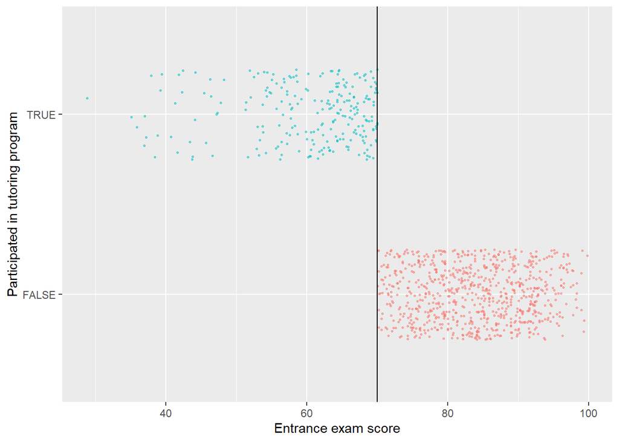

```r
ggplot(tutoring, aes(x = entrance_exam, y = tutoring, color = tutoring)) +
  # Make points small and semi-transparent since there are lots of them
  geom_point(size = 0.5, alpha = 0.5,
             position = position_jitter(width = 0, height = 0.25, seed = 1234)) +
  # Add vertical line
  geom_vline(xintercept = 70) +
  # Add labels
  labs(x = "Entrance exam score", y = "Participated in tutoring program") +
  # Turn off the color legend, since it's redundant
  guides(color = "none")
```

```r
tutoring %>%
  group_by(tutoring, entrance_exam <= 70) %>%
  summarize(count = n())
```

| tutoring | entrance_exam <= 70 | count |
| --- | --- | --- |
| FALSE | FALSE | 759 |
| TRUE | TRUE | 241 |

## 4.3 Paso 3: Verifique si hay discontinuidad al ejecutar la variable alrededor del punto de corte

A continuación, necesitamos ver si hubo alguna manipulación en la variable de ejecución; tal vez muchas personas se agruparon alrededor de 70 debido a cómo se calificó la prueba (es decir, los estudiantes querían ingresar al programa, por lo que deliberadamente obtuvieron malos resultados en el examen para obtener menores de 70 años). Podemos hacer esto de un par de maneras diferentes. Primero, haremos un histograma de la variable en ejecución (puntuaciones de las pruebas) y veremos si hay grandes saltos alrededor del umbral:

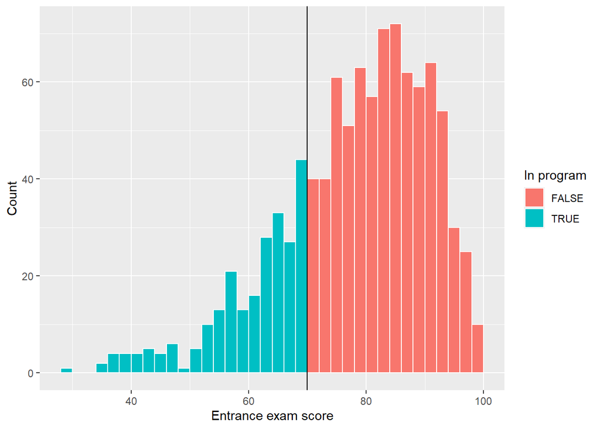

```r
ggplot(tutoring, aes(x = entrance_exam, fill = tutoring)) +
  geom_histogram(binwidth = 2, color = "white", boundary = 70) +
  geom_vline(xintercept = 70) +
  labs(x = "Entrance exam score", y = "Count", fill = "In program")
```

Aquí no parece que haya un salto alrededor del límite: hay una pequeña diferencia visible entre la altura de las barras justo antes y después del umbral de 70 puntos, pero parece seguir la forma general de la distribución general. Podemos comprobar si ese salto es estadísticamente significativo con una prueba de densidad de McCrary. Esto coloca los datos en contenedores como un histograma y luego traza los promedios y los intervalos de confianza de esos contenedores. Si los intervalos de confianza de las líneas de densidad no se superponen, entonces es probable que haya algo sistemáticamente incorrecto en la forma en que se calificó la prueba (es decir, demasiadas personas obtuvieron 69 frente a 71). Si los intervalos de confianza se superponen, no hay ninguna diferencia significativa alrededor del umbral y estamos bien.

Primero utilizamos rddensity()para hacer la prueba estadística real. Necesita alimentarlo con dos cosas: la variable de ejecución y el límite.

```r
# Notice this tutoring$entrance_exam syntax. This is one way for R to access
# columns in data frames---it means "use the entrance_exam column in the
# tutoring data frame". The general syntax for it is data_frame$column_name
test_density <- rddensity(tutoring$entrance_exam, c = 70)
summary(test_density)
```

```
##
## Manipulation testing using local polynomial density estimation.
##
## Number of obs =       1000
## Model =               unrestricted
## Kernel =              triangular
## BW method =           estimated
## VCE method =          jackknife
##
## c = 70                Left of c           Right of c
## Number of obs         237                 763
## Eff. Number of obs    208                 577
## Order est. (p)        2                   2
## Order bias (q)        3                   3
## BW est. (h)           22.444              19.966
##
## Method                T                   P > |T|
## Robust                -0.5521             0.5809
##
##
## P-values of binomial tests (H0: p=0.5).
##
## Window Length / 2          <c     >=c    P>|T|
## 0.900                      20      21    1.0000
## 1.800                      36      38    0.9076
## 2.700                      47      57    0.3776
## 3.600                      62      78    0.2047
## 4.500                      75      98    0.0941
## 5.400                      87     120    0.0259
## 6.300                     105     151    0.0048
## 7.200                     119     173    0.0019
## 8.100                     129     200    0.0001
## 9.000                     136     227    0.0000
```

Luego podemos trazar esa prueba de densidad:

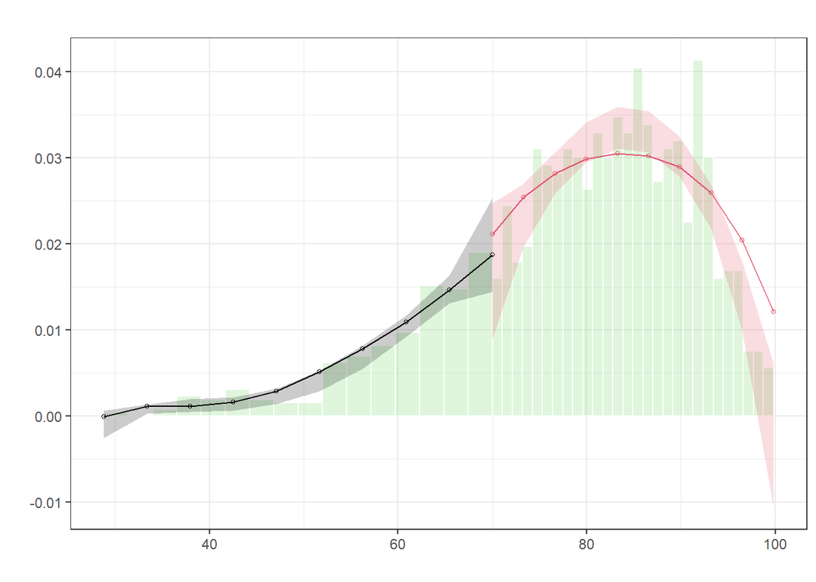

```r
# La sintaxis para rdplotdensity es un poco torpe aquí. Usted tiene que alimentar el
# la prueba rddensity(), y luego tienes que especificar x, que es tu variable de ejecución
# variable (¡otra vez!). El argumento tipo le dice al gráfico que muestre tanto puntos como # líneas.
# líneas---sin él, sólo mostrará líneas.
#
# Finalmente, observe cómo asigné la salida de rdplotdensity a una variable llamada
# plot_density_test. En teoría, esto debería hacer que no muestre nada---toda la salida # debería ir a ese objeto.
# salida debería ir a ese objeto. Debido a un error en rdplotdensity, sin embargo, se
# mostrará un gráfico automáticamente incluso si se asigna a una variable veremos dos gráficos idénticos, lo cual es
# molesto. Así que lo guardamos como una variable para ocultar la salida, pero obtener la salida
# de un solo gráfico de todos modos. Uf.
plot_density_test <- rdplotdensity(rdd = test_density,
                                   X = tutoring$entrance_exam,
                                   type = "both")  # This adds both points and lines
```

Hay muchos resultados aquí, pero lo que nos importa es la línea que comienza con “Robusto”, que muestra la prueba t para la diferencia en los dos puntos a cada lado del punto de corte en el gráfico. Observe en el gráfico que los intervalos de confianza se superponen sustancialmente. El valor p para el tamaño de esa superposición es 0,5809, que es mucho mayor que 0,05, por lo que no tenemos buena evidencia de que exista una diferencia significativa entre las dos líneas. Según este gráfico y el estadístico t, probablemente podamos decir con seguridad que no hay manipulación ni agrupamiento.

## 4.4 Paso 4: Verifique la discontinuidad en el resultado entre las variables en ejecución

Ahora que sabemos que este es un diseño elegante y que no hay acumulación de puntajes de exámenes alrededor del umbral de 70 puntos, finalmente podemos ver si hay una discontinuidad en los puntajes finales basados en la participación en el programa de tutoría. Trace la variable de ejecución en el eje x, la variable de resultado en el eje y, y coloree los puntos según si participaron en el programa.

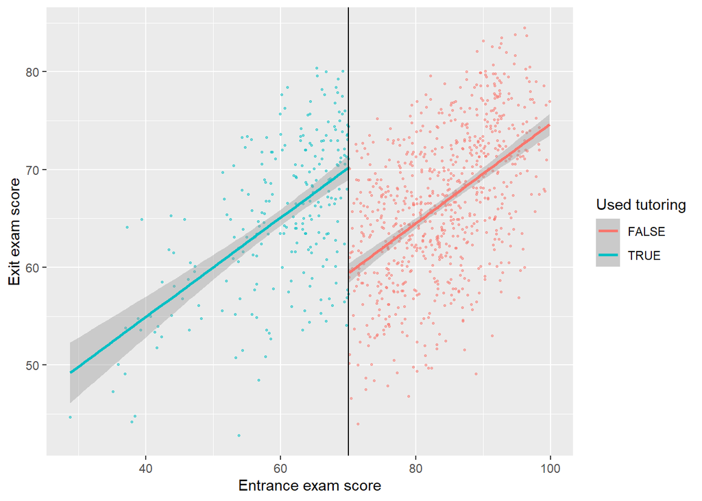

```r
ggplot(tutoring, aes(x = entrance_exam, y = exit_exam, color = tutoring)) +
  geom_point(size = 0.5, alpha = 0.5) +
  # Add a line based on a linear model for the people scoring 70 or less
  geom_smooth(data = filter(tutoring, entrance_exam <= 70), method = "lm") +
  # Add a line based on a linear model for the people scoring more than 70
  geom_smooth(data = filter(tutoring, entrance_exam > 70), method = "lm") +
  geom_vline(xintercept = 70) +
  labs(x = "Entrance exam score", y = "Exit exam score", color = "Used tutoring")
```

Según este gráfico, ¡hay una clara discontinuidad! Parece que la participación en el programa de tutoría mejoró las puntuaciones de las pruebas finales.

## 4.5 Paso 5: mide el tamaño del efecto

ay una discontinuidad, pero ¿qué tan grande es? ¿Y es estadísticamente significativo?

Podemos verificar el tamaño de dos maneras diferentes: de manera paramétrica (es decir, usando lm()parámetros y coeficientes específicos) y de manera no paramétrica (es decir, sin usar lm()ningún tipo de línea recta y en su lugar dibujando líneas que se ajusten a los datos con mayor precisión). Lo haremos en ambos sentidos.

**Estimación paramétrica**

Primero lo haremos paramétricamente usando regresión lineal. Aquí queremos explicar la variación en las puntuaciones finales en función de la puntuación del examen de acceso y la participación en el programa de tutorías:

$$\text{Exit exam} = \beta_0 + \beta_1
\text{Entrance exam score}_\text{centered} + \beta_2 \text{Tutoring
program} + \epsilon$$

Para facilitar la interpretación de los coeficientes, podemos centrar la columna del examen de ingreso para que, en lugar de mostrar el puntaje real del examen, muestre cuántos puntos por encima o por debajo de 70 obtuvo el estudiante. De esa manera podemos usar el coeficiente tutoringpara el efecto causal.

```r
tutoring_centered <- tutoring %>%
  mutate(entrance_centered = entrance_exam - 70)

model_simple <- lm(exit_exam ~ entrance_centered + tutoring,
                   data = tutoring_centered)
tidy(model_simple)
```

| term | estimate | std.error | statistic | p.value |
| --- | --- | --- | --- | --- |
| (Intercept) | 59.4108281 | 0.44193497 | 134.43342 | 0.000000e+00 |
| entrance_centered | 0.5097654 | 0.02691325 | 18.94106 | 1.398880e-68 |
| tutoringTRUE | 10.8004351 | 0.80043911 | 13.49314 | 3.117479e-38 |

Esto es lo que significan estos coeficientes:

-$\beta_0$: Esta es la intercepción. Debido a que centramos los puntajes de los exámenes de ingreso, muestra el puntaje promedio del examen de salida en el umbral de 70 puntos. Las personas que obtuvieron 70.001 puntos en el examen de ingreso obtienen una media de 59,4 puntos en el examen de salida. (Otra forma de pensar en esto es que muestra la puntuación prevista del examen de salida cuando entrance_centeredes 0 (es decir, 70) y cuando tutoringes FALSE.)

-$\beta_1$: Este es el coeficiente para entrance_centered. Por cada punto superior a 70 que las personas obtienen en el examen de ingreso, obtienen 0,51 puntos más en el examen de salida. Realmente no nos importa mucho este número.

-$\beta_2$: Este es el coeficiente del programa de tutoría y este es el que más nos importa . Este es el cambio en la intersección cuando tutoringes verdadero, o la diferencia entre puntuaciones en el umbral. Participar en el programa de tutoría aumenta los puntajes del examen de salida en 10,8 puntos.

Aquí ajustamos el modelo a todos los datos, pero en la vida real, lo que más nos importa son las observaciones que se encuentran alrededor del umbral, lo que significa que este modelo en realidad es **incorrecto** . Las puntuaciones que son muy altas o muy bajas no deberían influir realmente en el tamaño de nuestro efecto, ya que sólo nos preocupamos por las personas que obtienen una puntuación apenas inferior o ligeramente superior a 70.

Podemos ajustar el mismo modelo pero restringirlo a personas dentro de una ventana o ancho de banda más pequeño, como ±10 puntos o ±5 puntos:

```r
model_bw_10 <- lm(exit_exam ~ entrance_centered + tutoring,
                  data = filter(tutoring_centered,
                                entrance_centered >= -10 &
                                  entrance_centered <= 10))
tidy(model_bw_10)
```

| term | estimate | std.error | statistic | p.value |
| --- | --- | --- | --- | --- |
| (Intercept) | 60.3766097 | 0.7517824 | 80.311283 | 2.993271e-249 |
| entrance_centered | 0.3884462 | 0.1142982 | 3.398532 | 7.453336e-04 |
| tutoringTRUE | 9.2729759 | 1.3087406 | 7.085419 | 6.273792e-12 |

```r
model_bw_5 <- lm(exit_exam ~ entrance_centered + tutoring,
                  data = filter(tutoring_centered,
                                entrance_centered >= -5 &
                                  entrance_centered <= 5))
tidy(model_bw_5)
```

| term | estimate | std.error | statistic | p.value |
| --- | --- | --- | --- | --- |
| (Intercept) | 60.6311974 | 1.116836 | 54.288341 | 4.783168e-118 |
| entrance_centered | 0.3798729 | 0.331187 | 1.147004 | 2.528147e-01 |
| tutoringTRUE | 9.1216137 | 1.912453 | 4.769588 | 3.655799e-06 |

Podemos comparar todos estos modelos simultáneamente con modelsummary():

```r
modelsummary(list("Full data" = model_simple,
                  "Bandwidth = 10" = model_bw_10,
                  "Bandwidth = 5" = model_bw_5))
```

|  | Full data | Bandwidth = 10 | Bandwidth = 5 |
| --- | --- | --- | --- |
| (Intercept) | 59.411 | 60.377 | 60.631 |
|  | (0.442) | (0.752) | (1.117) |
| entrance_centered | 0.510 | 0.388 | 0.380 |
|  | (0.027) | (0.114) | (0.331) |
| tutoringTRUE | 10.800 | 9.273 | 9.122 |
|  | (0.800) | (1.309) | (1.912) |
| Num.Obs. | 1000 | 404 | 194 |
| R2 | 0.268 | 0.162 | 0.222 |
| R2 Adj. | 0.267 | 0.158 | 0.214 |
| AIC | 6595.3 | 2663.5 | 1303.1 |
| BIC | 6615.0 | 2679.5 | 1316.2 |
| Log.Lik. | -3293.663 | -1327.755 | -647.567 |
| F | 182.971 | 38.891 | 27.310 |
| RMSE | 6.52 | 6.47 | 6.81 |

l efecto tutoringdifiere mucho entre estos diferentes modelos, de 9,1 a 10,8. ¿Cuál es la correcta? No sé. Definitivamente no es el de datos completos.

Observe también cuánto cambia el tamaño de la muestra (N) entre los modelos. A medida que se reduce el ancho de banda, se analizan cada vez menos observaciones

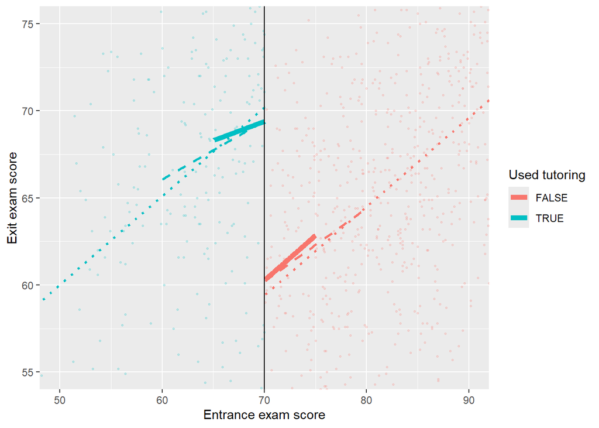

```r
ggplot(tutoring, aes(x = entrance_exam, y = exit_exam, color = tutoring)) +
  geom_point(size = 0.5, alpha = 0.2) +
  # Add lines for the full model (model_simple)
  geom_smooth(data = filter(tutoring, entrance_exam <= 70),
              method = "lm", se = FALSE, linetype = "dotted", size = 1) +
  geom_smooth(data = filter(tutoring, entrance_exam > 70),
              method = "lm", se = FALSE, linetype = "dotted", size = 1) +
  # Add lines for bandwidth = 10
  geom_smooth(data = filter(tutoring, entrance_exam <= 70, entrance_exam >= 60),
              method = "lm", se = FALSE, linetype = "dashed", size = 1) +
  geom_smooth(data = filter(tutoring, entrance_exam > 70, entrance_exam <= 80),
              method = "lm", se = FALSE, linetype = "dashed", size = 1) +
  # Add lines for bandwidth = 5
  geom_smooth(data = filter(tutoring, entrance_exam <= 70, entrance_exam >= 65),
              method = "lm", se = FALSE, size = 2) +
  geom_smooth(data = filter(tutoring, entrance_exam > 70, entrance_exam <= 75),
              method = "lm", se = FALSE, size = 2) +
  geom_vline(xintercept = 70) +
  # Zoom in
  coord_cartesian(xlim = c(50, 90), ylim = c(55, 75)) +
  labs(x = "Entrance exam score", y = "Exit exam score", color = "Used tutoring")
```

## 4.6 Estimación no paramétrica

En lugar de utilizar la regresión lineal para medir el tamaño de la discontinuidad, podemos utilizar métodos no paramétricos. Básicamente, esto significa que R no intentará ajustar una línea recta a los datos, sino que se curvará alrededor de los puntos e intentará ajustar todo lo más suavemente posible.

La rdrobust()función hace que sea realmente fácil medir la brecha en el punto de corte con una estimación no paramétrica. Aquí está la versión más simple:

```r
# Notice how we have to use the tutoring$exit_exam syntax here. Also make sure
# you set the cutoff with c
rdrobust(y = tutoring$exit_exam, x = tutoring$entrance_exam, c = 70) %>%
  summary()
```

```
## Sharp RD estimates using local polynomial regression.
##
## Number of Obs.                 1000
## BW type                       mserd
## Kernel                   Triangular
## VCE method                       NN
##
## Number of Obs.                  237          763
## Eff. Number of Obs.             144          256
## Order est. (p)                    1            1
## Order bias  (q)                   2            2
## BW est. (h)                   9.969        9.969
## BW bias (b)                  14.661       14.661
## rho (h/b)                     0.680        0.680
## Unique Obs.                     155          262
##
## =============================================================================
##         Method     Coef. Std. Err.         z     P>|z|      [ 95% C.I. ]
## =============================================================================
##   Conventional    -8.578     1.601    -5.359     0.000   [-11.715 , -5.441]
##         Robust         -         -    -4.352     0.000   [-12.101 , -4.587]
## =============================================================================
```

Hay algunos datos importantes que considerar en este resultado:

Lo que más le importa es el tamaño real del efecto. Este es el coeficiente de la tabla inferior, indicado con el método “Convencional”. Aquí es -8,578, lo que significa que el programa de tutoría provoca un cambio de 8 puntos en las puntuaciones de los exámenes de salida. La tabla en la parte inferior también incluye errores estándar, valores p e intervalos de confianza para el coeficiente, tanto estimaciones normales (convencionales) como estimaciones robustas (robustas). Según ambos tipos de estimaciones, este aumento de 8 puntos es estadísticamente significativo (p < 0,001; el intervalo de confianza del 95% definitivamente nunca incluye 0).

Es importante señalar que el coeficiente aquí es en realidad negativo (-8,578), mientras que nuestras estimaciones paramétricas anteriores eran todas positivas. Eso no significa que el programa provoque una caída en los puntajes de las pruebas. Ese valor negativo es sólo un efecto secundario de cómo rdrobust()se mide la brecha. Observa el valor del grupo de tratamiento justo antes del umbral y luego muestra que los puntajes de las pruebas caen al pasar al grupo de control (mientras que antes hablamos de la historia opuesta: los puntajes de las pruebas aumentan a medida que se pasa del grupo de control al grupo de tratamiento). ). No hay forma de voltear el letrero dentro rdrobust(), por lo que debes mirar la trama y ver qué está haciendo realmente la brecha.

El modelo utilizó un ancho de banda de 9,969 ( BW est. (h)en la salida), lo que significa que solo miró a personas con puntuaciones de prueba de 70 ± 10. Decidió este ancho de banda automáticamente, pero puedes cambiarlo a lo que quieras.

El modelo utilizó un núcleo triangular. Esta es la parte más esotérica del modelo: el núcleo decide cuánto peso dar a las observaciones alrededor del límite. Los puntajes de exámenes como 69,99 o 70,01 están muy cerca de 70, por lo que obtienen el mayor peso. Puntuaciones como 67 o 73 están un poco más alejadas, por lo que importan menos. Puntuaciones como 64 o 76 importan aún menos, por lo que obtienen aún menos peso.

```
## [1] "Mass points detected in the running variable."
```

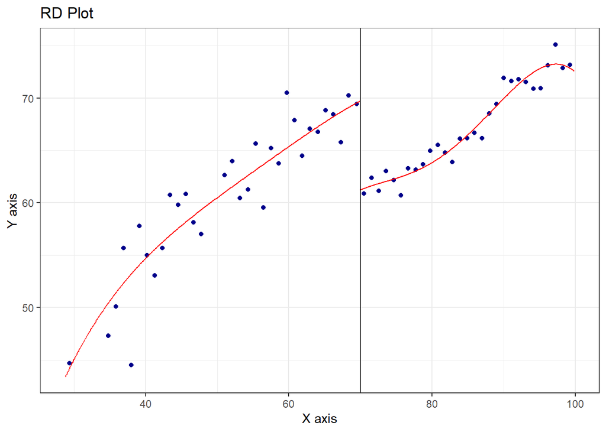

```r
asdf <- rdplot(y = tutoring$exit_exam, x = tutoring$entrance_exam, c = 70)
```

¡Mira ese salto de 8,5 puntos a los 70! ¡Limpio!

Observe que los puntos aquí no son en realidad las observaciones del conjunto de datos. La rdplot()función crea grupos de puntos (como un histograma) y luego muestra el resultado promedio dentro de cada grupo. Puede controlar cuántos contenedores se utilizan en el eje x con los argumentos nbinso binselecten rdplot()(ejecútelo ?rdploten su consola para ver todas las opciones posibles para trazar discontinuidades no paramétricas).

**NOTA** Nota al margen : rdplot()utiliza el mismo sistema de trazado que ggplot(), por lo que puedes agregar capas como labs()o geom_point()cualquier otra cosa, lo cual es genial, pero llegar a ese ggplot()objeto subyacente es extraño. Para hacerlo, almacene los resultados de rdplotcomo un objeto, como asdfy luego use asdf$rdplotpara acceder al gráfico:

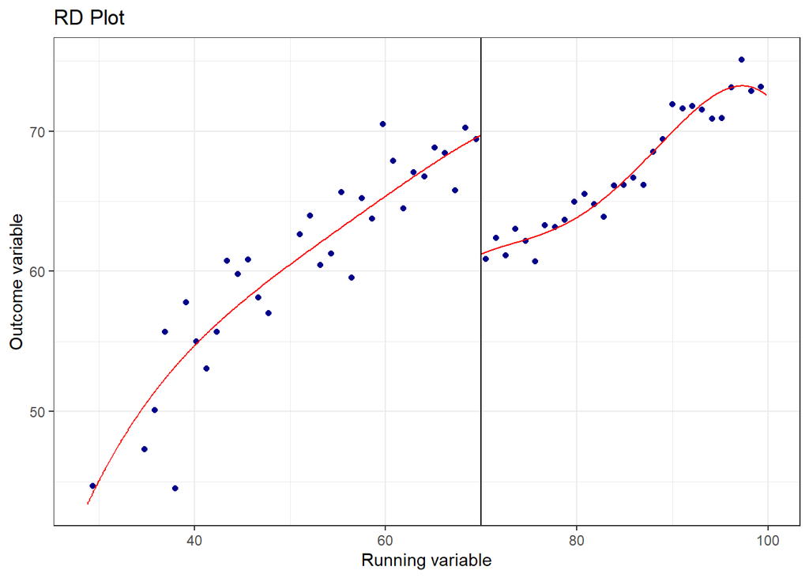

```r
asdf$rdplot +
  labs(x = "Running variable", y = "Outcome variable")
```

De forma predeterminada, rdrobust()elige automáticamente el tamaño del ancho de banda basándose en sofisticados algoritmos que han desarrollado los economistas. Puede usarlo rdbwselect()para ver cuál es ese ancho de banda y, si incluye el all = TRUEargumento, puede ver varios anchos de banda potenciales diferentes basados en varios algoritmos diferentes:

```r
# This says to use the mserd version, which according to the help file for
# rdbwselect means "the mean squared error-optimal bandwidth selector for RD
# treatment effects". Sounds great.
rdbwselect(y = tutoring$exit_exam, x = tutoring$entrance_exam, c = 70) %>%
  summary()
```

```
## Call: rdbwselect
##
## Number of Obs.                 1000
## BW type                       mserd
## Kernel                   Triangular
## VCE method                       NN
##
## Number of Obs.                  237          763
## Order est. (p)                    1            1
## Order bias  (q)                   2            2
## Unique Obs.                     155          262
##
## =======================================================
##                   BW est. (h)    BW bias (b)
##             Left of c Right of c  Left of c Right of c
## =======================================================
##      mserd     9.969      9.969     14.661     14.661
## =======================================================
```

¿Cuáles son los diferentes anchos de banda posibles que podríamos utilizar?

```r
rdbwselect(y = tutoring$exit_exam, x = tutoring$entrance_exam, c = 70, all = TRUE) %>%
  summary()
```

```
## Call: rdbwselect
##
## Number of Obs.                 1000
## BW type                         All
## Kernel                   Triangular
## VCE method                       NN
##
## Number of Obs.                  237          763
## Order est. (p)                    1            1
## Order bias  (q)                   2            2
## Unique Obs.                     155          262
##
## =======================================================
##                   BW est. (h)    BW bias (b)
##             Left of c Right of c  Left of c Right of c
## =======================================================
##      mserd     9.969      9.969     14.661     14.661
##     msetwo    11.521     10.054     17.067     14.907
##     msesum    12.044     12.044     17.631     17.631
##   msecomb1     9.969      9.969     14.661     14.661
##   msecomb2    11.521     10.054     17.067     14.907
##      cerrd     7.058      7.058     14.661     14.661
##     certwo     8.156      7.118     17.067     14.907
##     cersum     8.526      8.526     17.631     17.631
##   cercomb1     7.058      7.058     14.661     14.661
##   cercomb2     8.156      7.118     17.067     14.907
## =======================================================
```

Otro enfoque común para el análisis de sensibilidad es utilizar el ancho de banda ideal, el doble del ideal y la mitad del ideal (en nuestro caso, 10, 20 y 5) y ver si la estimación cambia sustancialmente. Utilice el hargumento para especificar su propio ancho de banda

```r
rdrobust(y = tutoring$exit_exam, x = tutoring$entrance_exam, c = 70, h = 9.969) %>%
  summary()
```

```
## Sharp RD estimates using local polynomial regression.
##
## Number of Obs.                 1000
## BW type                      Manual
## Kernel                   Triangular
## VCE method                       NN
##
## Number of Obs.                  237          763
## Eff. Number of Obs.             144          256
## Order est. (p)                    1            1
## Order bias  (q)                   2            2
## BW est. (h)                   9.969        9.969
## BW bias (b)                   9.969        9.969
## rho (h/b)                     1.000        1.000
## Unique Obs.                     237          763
##
## =============================================================================
##         Method     Coef. Std. Err.         z     P>|z|      [ 95% C.I. ]
## =============================================================================
##   Conventional    -8.578     1.601    -5.359     0.000   [-11.715 , -5.441]
##         Robust         -         -    -3.276     0.001   [-12.483 , -3.138]
## =============================================================================
```

```r
rdrobust(y = tutoring$exit_exam, x = tutoring$entrance_exam, c = 70, h = 9.969 * 2) %>%
  summary()
```

```
## Sharp RD estimates using local polynomial regression.
##
## Number of Obs.                 1000
## BW type                      Manual
## Kernel                   Triangular
## VCE method                       NN
##
## Number of Obs.                  237          763
## Eff. Number of Obs.             206          577
## Order est. (p)                    1            1
## Order bias  (q)                   2            2
## BW est. (h)                  19.938       19.938
## BW bias (b)                  19.938       19.938
## rho (h/b)                     1.000        1.000
## Unique Obs.                     237          763
##
## =============================================================================
##         Method     Coef. Std. Err.         z     P>|z|      [ 95% C.I. ]
## =============================================================================
##   Conventional    -9.151     1.130    -8.100     0.000   [-11.365 , -6.937]
##         Robust         -         -    -4.980     0.000   [-11.670 , -5.078]
## =============================================================================
```

```r
rdrobust(y = tutoring$exit_exam, x = tutoring$entrance_exam, c = 70, h = 9.969 / 2) %>%
  summary()
```

```
## Sharp RD estimates using local polynomial regression.
##
## Number of Obs.                 1000
## BW type                      Manual
## Kernel                   Triangular
## VCE method                       NN
##
## Number of Obs.                  237          763
## Eff. Number of Obs.              82          109
## Order est. (p)                    1            1
## Order bias  (q)                   2            2
## BW est. (h)                   4.984        4.984
## BW bias (b)                   4.984        4.984
## rho (h/b)                     1.000        1.000
## Unique Obs.                     237          763
##
## =============================================================================
##         Method     Coef. Std. Err.         z     P>|z|      [ 95% C.I. ]
## =============================================================================
##   Conventional    -8.201     2.348    -3.493     0.000   [-12.803 , -3.600]
##         Robust         -         -    -2.032     0.042   [-13.618 , -0.246]
## =============================================================================
```

Aquí los coeficientes cambian ligeramente:

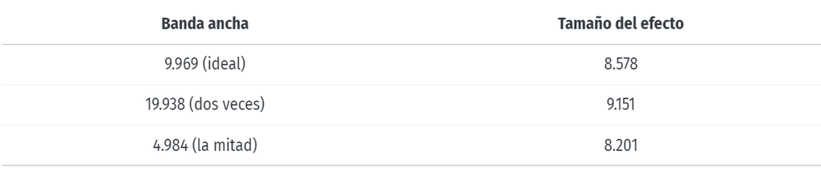

También puedes ajustar el kernel. Por defecto rd_robustutiliza un kernel triangular (las observaciones más distantes tienen menos peso linealmente), pero puedes cambiarlo a Epanechnikov (las observaciones más distantes tienen menos peso siguiendo una curva) o uniforme (las observaciones más distantes tienen el mismo peso que las observaciones más cercanas; esto es no ponderado).

```r
# Non-parametric RD with different kernels
rdrobust(y = tutoring$exit_exam, x = tutoring$entrance_exam,
         c = 70, kernel = "triangular") %>%
  summary()
```

```
## Sharp RD estimates using local polynomial regression.
##
## Number of Obs.                 1000
## BW type                       mserd
## Kernel                   Triangular
## VCE method                       NN
##
## Number of Obs.                  237          763
## Eff. Number of Obs.             144          256
## Order est. (p)                    1            1
## Order bias  (q)                   2            2
## BW est. (h)                   9.969        9.969
## BW bias (b)                  14.661       14.661
## rho (h/b)                     0.680        0.680
## Unique Obs.                     155          262
##
## =============================================================================
##         Method     Coef. Std. Err.         z     P>|z|      [ 95% C.I. ]
## =============================================================================
##   Conventional    -8.578     1.601    -5.359     0.000   [-11.715 , -5.441]
##         Robust         -         -    -4.352     0.000   [-12.101 , -4.587]
## =============================================================================
```

```r
rdrobust(y = tutoring$exit_exam, x = tutoring$entrance_exam,
         c = 70, kernel = "epanechnikov") %>%
  summary()
```

```
## Sharp RD estimates using local polynomial regression.
##
## Number of Obs.                 1000
## BW type                       mserd
## Kernel                   Epanechnikov
## VCE method                       NN
##
## Number of Obs.                  237          763
## Eff. Number of Obs.             130          204
## Order est. (p)                    1            1
## Order bias  (q)                   2            2
## BW est. (h)                   8.201        8.201
## BW bias (b)                  12.807       12.807
## rho (h/b)                     0.640        0.640
## Unique Obs.                     155          262
##
## =============================================================================
##         Method     Coef. Std. Err.         z     P>|z|      [ 95% C.I. ]
## =============================================================================
##   Conventional    -8.389     1.677    -5.001     0.000   [-11.677 , -5.101]
##         Robust         -         -    -4.085     0.000   [-12.116 , -4.260]
## =============================================================================
```

```r
rdrobust(y = tutoring$exit_exam, x = tutoring$entrance_exam,
         c = 70, kernel = "uniform") %>%
  summary()
```

```
## Sharp RD estimates using local polynomial regression.
##
## Number of Obs.                 1000
## BW type                       mserd
## Kernel                      Uniform
## VCE method                       NN
##
## Number of Obs.                  237          763
## Eff. Number of Obs.             119          176
## Order est. (p)                    1            1
## Order bias  (q)                   2            2
## BW est. (h)                   7.346        7.346
## BW bias (b)                  12.561       12.561
## rho (h/b)                     0.585        0.585
## Unique Obs.                     155          262
##
## =============================================================================
##         Method     Coef. Std. Err.         z     P>|z|      [ 95% C.I. ]
## =============================================================================
##   Conventional    -8.175     1.651    -4.952     0.000   [-11.411 , -4.939]
##         Robust         -         -    -4.085     0.000   [-11.704 , -4.115]
## =============================================================================
```

De nuevo, los coeficientes cambian ligeramente:

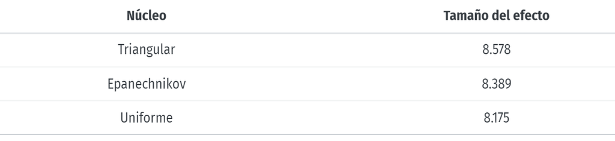

¿Cuál es el mejor? ¯_(ツ)_/¯. Lo único que realmente importa es que el tamaño y la dirección del efecto no cambien. Sigue siendo positivo y todavía está en el rango de 8 a 9 puntos.

## 4.7 Paso 6: compara todos los efectos

Acabamos de estimar una tonelada de tamaños de efectos. En la vida real, generalmente solo informarías uno de estos como tu efecto final, pero ejecutarías los diferentes modelos paramétricos y no paramétricos para comprobar qué tan confiables y sólidos son tus hallazgos. Aquí está todo lo que acabamos de encontrar:

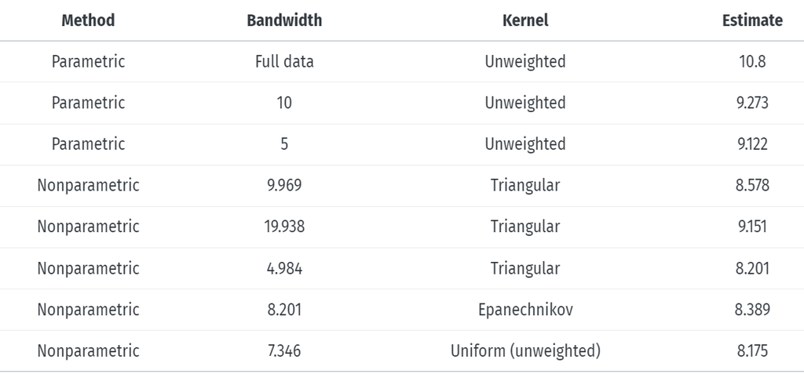

En la vida real, probablemente informaría el más simple (fila 4: no paramétrico, ancho de banda automático, núcleo triangular), pero es útil saber cuánto varía el efecto según las especificaciones del modelo.

# 5 Instrumental Variables

Las variables instrumentales (IV) son una técnica utilizada en econometría y estadística para abordar problemas de endogeneidad en modelos de regresión. La endogeneidad ocurre cuando una variable explicativa está correlacionada con el término de error, lo que puede sesgar los resultados de la estimación. Las variables instrumentales ayudan a obtener estimaciones no sesgadas y consistentes en presencia de este problema.

Imagina que queremos estudiar el efecto de la educación en el salario. Podríamos usar la siguiente regresión:

$Salario=β_0+β_1*Educación + ϵ$

Donde:

- Salario: variable dependiente (lo que queremos explicar).
- Educación: variable independiente (lo que creemos que afecta al salario).
- $β_0$ y $β_1$: coeficientes a estimar.
- $ϵ$ término de error (captura otros factores que afectan al salario).

Problema de Endogeneidad El problema surge si la variable Educación está correlacionada con el término de error $ϵ$. Por ejemplo, si hay factores no observables como la habilidad innata o la motivación que afectan tanto a la educación como al salario, entonces:

$$Cov(Educación,ϵ) != 0$$

**ejemplo** Para todos estos ejemplos, nos interesa la eterna cuestión econométrica de si un año adicional de educación provoca aumentos salariales. A los economistas les encantan estas cosas.

Exploraremos la pregunta con tres conjuntos de datos diferentes: uno falso inventado y dos reales de investigaciones publicadas.

Asegúrese de cargar todas estas bibliotecas antes de comenzar:

```r
library(tidyverse)  # ggplot(), %>%, mutate(), and friends
library(broom)  # Convert models to data frames
library(modelsummary)  # Create side-by-side regression tables
library(kableExtra)  # Add fancier formatting to tables
library(estimatr)  # Run 2SLS models in one step with iv_robust()
```

## 5.1 Educación, salarios y educación del padre (datos falsos)

Primero usemos algunos datos falsos para ver si la educación genera salarios adicionales.

```r
ed_fake <- read_csv("father_education.csv")
```

El archivo father_education.csv contiene cuatro variables:

- wage Salario semanal
- educ Años de educación
- ability Columna mágica que mide tu capacidad para trabajar e ir a la escuela (variable omitida)
- fathereduc Años de educación para el padre.

### 5.1.1 modelo ingenuo

Si realmente pudiéramos medir la capacidad, podríamos estimar este modelo, que cierra la confusa puerta trasera que plantea la capacidad y aísla sólo el efecto de la educación sobre los salarios:

```r
model_forbidden <- lm(wage ~ educ + ability, data = ed_fake)
tidy(model_forbidden)
```

| term | estimate | std.error | statistic | p.value |
| --- | --- | --- | --- | --- |
| (Intercept) | -85.5708977 | 7.19774238 | -11.88857 | 1.415018e-30 |
| educ | 7.7673490 | 0.45550443 | 17.05219 | 2.080021e-57 |
| ability | 0.3444126 | 0.01037329 | 33.20186 | 2.141851e-163 |

Sin embargo, en la vida real no tenemos ability, por lo que nos quedamos atrapados en un modelo ingenuo:

```r
model_naive <- lm(wage ~ educ, data = ed_fake)
tidy(model_naive)
```

| term | estimate | std.error | statistic | p.value |
| --- | --- | --- | --- | --- |
| (Intercept) | -59.37847 | 10.3764931 | -5.722402 | 1.388017e-08 |
| educ | 13.12406 | 0.6178207 | 21.242502 | 6.474668e-83 |

El modelo ingenuo sobreestima el efecto de la educación sobre los salarios (13.1 frente a 7.8 ) debido al sesgo de la variable omitida. La educación adolece de endogeneidad: hay cosas en el modelo (como la capacidad, oculta en el término de error) que están correlacionadas con él. Cualquier estimación que calculemos será errónea y estará sesgada debido a efectos de selección o sesgo de variable omitida (todos nombres diferentes para la endogeneidad).

### 5.1.2 Verificar la validez del instrumento

Para solucionar el problema de la endogeneidad, podemos utilizar un instrumento para eliminar la endogeneidad de la educación y, en su lugar, utilizar una versión especial de la educación basada únicamente en la exogeneidad. Quizás la educación del padre de alguien pueda ser un instrumento para la educación (no es el mejor instrumento, pero lo seguiremos).

Para que un instrumento sea válido, debe cumplir tres criterios:

1. Relevancia : el instrumento está correlacionado con la variable de política.
2. Exclusión : El instrumento se correlaciona con el resultado sólo a través de la variable de política.
3. Exogeneidad : el instrumento no está correlacionado con nada más en el modelo (es decir, variables omitidas)

#### 5.1.2.1 Relevancia

Primero podemos probar la relevancia haciendo un diagrama de dispersión y ejecutando un modelo de policy ~ instrument:

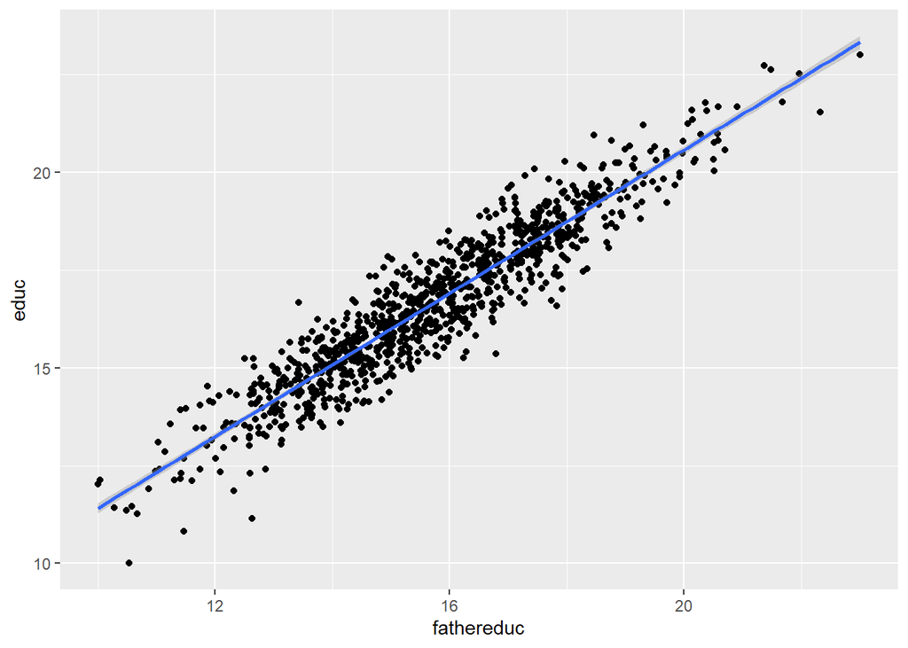

```r
ggplot(ed_fake, aes(x = fathereduc, y = educ)) +
  geom_point() +
  geom_smooth(method = "lm")
```

```r
check_relevance <- lm(educ ~ fathereduc, data = ed_fake)
tidy(check_relevance)
```

| term | estimate | std.error | statistic | p.value |
| --- | --- | --- | --- | --- |
| (Intercept) | 2.2509868 | 0.17219199 | 13.07254 | 3.665537e-36 |
| fathereduc | 0.9161954 | 0.01084572 | 84.47525 | 0.000000e+00 |

```r
glance(check_relevance)
```

| r.squared | adj.r.squared | sigma | statistic | p.value | df | logLik | AIC | BIC | deviance | df.residual | nobs |
| --- | --- | --- | --- | --- | --- | --- | --- | --- | --- | --- | --- |
| 0.8773062 | 0.8771832 | 0.703036 | 7136.068 | 0 | 1 | -1065.59 | 2137.181 | 2151.904 | 493.2711 | 998 | 1000 |

¡Esto se ve bastante bien! La estadística F está definitivamente por encima de 10 (¡es 7.136!) y existe una relación significativa entre el instrumento y la política. Yo diría que esto es relevante.

#### 5.1.2.2 Exclusión

Para comprobar la exclusión, necesitamos ver si existe una relación entre la educación del padre y los salarios que se produce sólo debido a la educación. Si lo trazamos, veremos una relación:

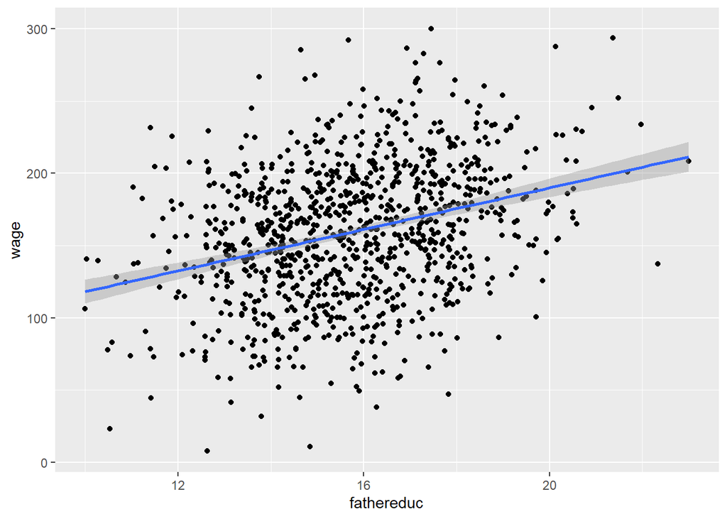

```r
ggplot(ed_fake, aes(x = fathereduc, y = wage)) +
  geom_point() +
  geom_smooth(method = "lm")
```

Esto es de esperarse, ya que en nuestro modelo la educación del padre causa educación, la cual causa los salarios; deberían estar correlacionados. Pero tenemos que utilizar una historia y una teoría convincentes para justificar la idea de que la educación de un padre aumenta el salario por hora sólo porque aumenta la educación de uno , y no existe una prueba estadística real para eso. Buena suerte.

#### 5.1.2.3 Exogeneidad

En realidad, tampoco existe una prueba de exogeneidad, ya que no hay forma de medir otras variables endógenas en el modelo (¡esa es la razón por la que usamos IV en primer lugar!). Como tenemos la abilitycolumna mágica en estos datos falsos, podemos probarla. La educación del padre no debe estar relacionada con la capacidad:

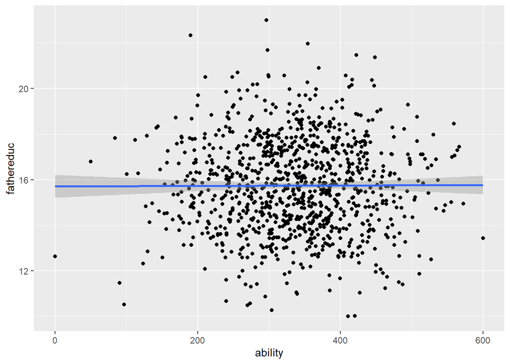

```r
ggplot(ed_fake, aes(x = ability, y = fathereduc)) +
  geom_point() +
  geom_smooth(method = "lm")
```

¡Y no lo es! Podemos decir con seguridad que cumple con el supuesto de exogeneidad.

En la vida real, aunque no existe una prueba estadística de exogeneidad. Sólo tenemos que contar una historia basada en la teoría de que el número de años de educación que tiene el padre de uno no está correlacionado con nada más en el modelo (incluidas las variables omitidas). Buena suerte con eso; probablemente no sea un buen instrumento. Esto se relaciona con el argumento de Scott Cunningham de que los instrumentos tienen que ser extraños. Según Scott :

La razón por la que creo esto es porque un instrumento no pertenece al término de error estructural y el término de error estructural son todas las cosas intuitivas que determinan el resultado. Debe ser extraño, de lo contrario probablemente esté en el término de error.

Finjamos que la educación del padre es un instrumento válido y sigamos adelante :)

### 5.1.3 regresión de mínimos cuadrados

Ahora podemos hacer una regresión de mínimos cuadrados en dos etapas (2SLS) y usar el instrumento para filtrar la parte endógena de la educación. La primera etapa predice la educación basada en el instrumento (ya ejecutamos este modelo anteriormente cuando verificamos la relevancia, pero lo haremos nuevamente solo por diversión):

```r
first_stage <- lm(educ ~ fathereduc, data = ed_fake)
```

Ahora queremos agregar una columna de educación prevista a nuestro conjunto de datos original. La forma más sencilla de hacerlo es con la augment_columns()función de la biblioteca broom , que conecta valores de un conjunto de datos a un modelo para generar predicciones:

```r
ed_fake_with_prediction <- augment_columns(first_stage, ed_fake)
head(ed_fake_with_prediction)
```

| wage | educ | ability | fathereduc | .fitted | .se.fit | .resid | .hat | .sigma | .cooksd | .std.resid |
| --- | --- | --- | --- | --- | --- | --- | --- | --- | --- | --- |
| 180.37 | 18.54 | 408.48 | 17.15 | 17.96374 | 0.02696158 | 0.57626285 | 0.001470739 | 0.7031513 | 4.955301e-04 | 0.8202810 |
| 100.23 | 16.24 | 309.92 | 15.49 | 16.44285 | 0.02240145 | -0.20285286 | 0.001015306 | 0.7033591 | 4.235029e-05 | -0.2886850 |
| 124.56 | 18.19 | 302.91 | 17.68 | 18.44932 | 0.03058316 | -0.25932068 | 0.001892385 | 0.7033405 | 1.292242e-04 | -0.3692078 |
| 177.59 | 16.55 | 342.21 | 15.55 | 16.49782 | 0.02233089 | 0.05217542 | 0.001008920 | 0.7033865 | 2.784071e-06 | 0.0742519 |
| 265.37 | 17.34 | 534.46 | 14.74 | 15.75571 | 0.02475354 | 1.58429366 | 0.001239708 | 0.7015944 | 3.155610e-03 | 2.2549010 |
| 186.89 | 17.46 | 408.54 | 15.97 | 16.88263 | 0.02236714 | 0.57737337 | 0.001012199 | 0.7031505 | 3.420376e-04 | 0.8216731 |

Tenga en cuenta un par de estas nuevas columnas. .fittedes el valor ajustado/predicho de la educación, y es la versión de la educación en la que posiblemente se elimina la endogeneidad. .residmuestra qué tan lejos está la predicción de educ. Las otras columnas no importan tanto.

En lugar de lidiar con nombres extraños como .fitted, me gusta cambiar el nombre de la variable ajustada a algo más comprensible después de usar augment_columns:

```r
ed_fake_with_prediction <- augment_columns(first_stage, ed_fake) %>%
  rename(educ_hat = .fitted)

head(ed_fake_with_prediction)
```

| wage | educ | ability | fathereduc | educ_hat | .se.fit | .resid | .hat | .sigma | .cooksd | .std.resid |
| --- | --- | --- | --- | --- | --- | --- | --- | --- | --- | --- |
| 180.37 | 18.54 | 408.48 | 17.15 | 17.96374 | 0.02696158 | 0.57626285 | 0.001470739 | 0.7031513 | 4.955301e-04 | 0.8202810 |
| 100.23 | 16.24 | 309.92 | 15.49 | 16.44285 | 0.02240145 | -0.20285286 | 0.001015306 | 0.7033591 | 4.235029e-05 | -0.2886850 |
| 124.56 | 18.19 | 302.91 | 17.68 | 18.44932 | 0.03058316 | -0.25932068 | 0.001892385 | 0.7033405 | 1.292242e-04 | -0.3692078 |
| 177.59 | 16.55 | 342.21 | 15.55 | 16.49782 | 0.02233089 | 0.05217542 | 0.001008920 | 0.7033865 | 2.784071e-06 | 0.0742519 |
| 265.37 | 17.34 | 534.46 | 14.74 | 15.75571 | 0.02475354 | 1.58429366 | 0.001239708 | 0.7015944 | 3.155610e-03 | 2.2549010 |
| 186.89 | 17.46 | 408.54 | 15.97 | 16.88263 | 0.02236714 | 0.57737337 | 0.001012199 | 0.7031505 | 3.420376e-04 | 0.8216731 |

Ahora podemos usar la nueva educ_hatvariable en nuestro modelo de segunda etapa:

```r
second_stage <- lm(wage ~ educ_hat, data = ed_fake_with_prediction)
tidy(second_stage)
```

| term | estimate | std.error | statistic | p.value |
| --- | --- | --- | --- | --- |
| (Intercept) | 28.818695 | 12.6724054 | 2.27413 | 2.316979e-02 |
| educ_hat | 7.834935 | 0.7551808 | 10.37491 | 5.096425e-24 |

Podría decirse que la estimación educ_hates más precisa ahora porque hemos utilizado el instrumento para eliminar la parte endógena de la educación y solo deberíamos tener la parte exógena.

Hacer todo ese trabajo en dos etapas es interesante y ayuda con la intuición de las variables instrumentales, pero es tedioso. Más importante aún, los errores estándar educ_hatson incorrectos y el $R^2$ y otros diagnósticos para el modelo de segunda etapa también son incorrectos. Puedes usar matemáticas sofisticadas para ajustar estas cosas en la segunda etapa, pero no vamos a hacer eso. En su lugar, usaremos una función que realiza ambas etapas del modelo 2SLS al mismo tiempo.

Hay varias funciones de diferentes paquetes de R que le permiten realizar 2SLS, y todas funcionan de manera un poco diferente y tienen diferentes beneficios:

- iv_robust()de estimation :

Sintaxis:outcome ~ treatment | instrument Beneficios: Maneja errores estándar robustos y agrupados

- ivreg()de ivreg :

Sintaxis:outcome ~ treatment | instrument Beneficios: Incluye un montón de diagnósticos sofisticados

- ivreg()de AER :

Sintaxis:outcome ~ treatment | instrument Beneficios: Incluye pruebas especiales para instrumentos débiles (que son mejores que el estándar “verificar si F > 10”), como los intervalos de confianza de Anderson-Rubin.

- lfe()de fel :

Sintaxis:outcome ~ treatment | fixed effects | instrument Beneficios: Maneja los efectos fijos muy rápidamente (algo así como feols()los que usaste en la Serie de problemas 5)

- plm()de plm : Sintaxis:outcome ~ treatment | instrument Beneficios: Maneja datos de panel (país/año, estado/año, etc.)

Esta página [aquí](https://raw.githack.com/uo-ec607/lectures/master/08-regression/08-regression.html#Instrumental_variables) tiene ejemplos más detallados de los tres principales: iv_robust(), ivreg() y lfe()

Nosotros solo usaremos iv_robust(). En lugar de ejecutar una primera etapa, generar predicciones y ejecutar una segunda etapa, podemos hacerlo todo a la vez de esta manera:

```r
model_2sls <- iv_robust(wage ~ educ | fathereduc,
                        data = ed_fake)
tidy(model_2sls)
```

| term | estimate | std.error | statistic | p.value | conf.low | conf.high | df | outcome |
| --- | --- | --- | --- | --- | --- | --- | --- | --- |
| (Intercept) | 28.818695 | 11.1645893 | 2.581259 | 9.985789e-03 | 6.909932 | 50.727459 | 998 | wage |
| educ | 7.834935 | 0.6635423 | 11.807739 | 3.281862e-30 | 6.532837 | 9.137033 | 998 | wage |

El coeficiente educaquí es el mismo que educ_hatel del modelo 2SLS manual, ¡pero aquí lo encontramos en una línea de código! Además, los errores y diagnósticos estándar del modelo son todos correctos ahora.

## 5.2 Educación, salarios y educación de los padres (múltiples instrumentos) (datos reales)

Estos datos provienen del wage2 conjunto de datos del paquete Wooldridge R (¡y son reales!). Los datos se utilizaron en este artículo:

[M. Blackburn y D. Neumark (1992), “Unobserved Ability, Efficiency Wages, and Interindustry Wage Differentials”, Quarterly Journal of Economics 107, 1421-1436.](https://doi.org/10.3386/w3857)

```r
wage2 <- read_csv("wage2.csv")
```

Este conjunto de datos incluye un montón de variables diferentes. Si ejecuta library(wooldridge)y luego ejecuta, ?wagepodrá ver la documentación de los datos. Estas son las variables que nos interesan para este ejemplo:

**variables**

- wage Salario mensual (dólares de 1980)
- educ Años de educación
- feduc Años de educación para el padre.
- meduc Años de educación para la madre.

Para hacer la vida más fácil, cambiaremos el nombre de algunas de las columnas y eliminaremos las filas a las que les faltan datos:

```r
ed_real <- wage2 %>%
  rename(education = educ, education_dad = feduc, education_mom = meduc) %>%
  na.omit()  # Get rid of rows with missing values
```

### 5.2.1 modelo ingenuo

```r
model_naive <- lm(wage ~ education, data = ed_real)
tidy(model_naive)
```

| term | estimate | std.error | statistic | p.value |
| --- | --- | --- | --- | --- |
| (Intercept) | 175.15999 | 92.838561 | 1.886716 | 5.963657e-02 |
| education | 59.45181 | 6.697942 | 8.876132 | 6.452702e-18 |

¡Pero esto está mal! La educación es endógena a las cosas no medidas en el modelo (como la capacidad, que vive en el término de error). Podemos aislar la parte exógena de la educación con un instrumento.

### 5.2.2 Verificar la validez del instrumento

Antes de realizar cualquier modelo 2SLS, queremos comprobar la validez de los instrumentos. Recuerde, para que un instrumento sea válido, debe cumplir con estos criterios:

- Relevancia : el instrumento está correlacionado con la variable de política.
- Exclusión : El instrumento se correlaciona con el resultado sólo a través de la variable de política.
- Exogeneidad : el instrumento no está correlacionado con nada más en el modelo (es decir, variables omitidas)

#### 5.2.2.1 Relevancia

Podemos verificar la relevancia observando la relación entre los instrumentos y la educación:

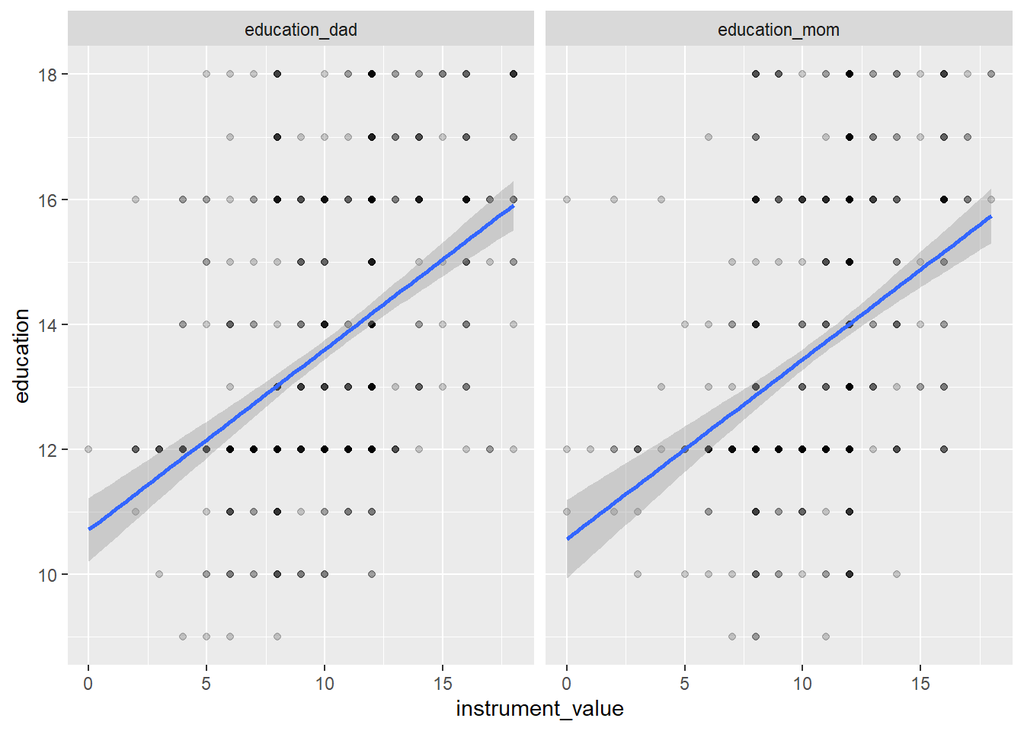

```r
# Combine father's and mother's education into one column so we can plot both at the same time
ed_real_long <- ed_real %>%
  pivot_longer(cols = c(education_dad, education_mom),
               names_to = "instrument", values_to = "instrument_value")

ggplot(ed_real_long, aes(x = instrument_value, y = education)) +
  # Make points semi-transparent because of overplotting
  geom_point(alpha = 0.2) +
  geom_smooth(method = "lm") +
  facet_wrap(vars(instrument))
```

```r
model_check_instruments <- lm(education ~ education_dad + education_mom,
                              data = ed_real)
tidy(model_check_instruments)
```

| term | estimate | std.error | statistic | p.value |
| --- | --- | --- | --- | --- |
| (Intercept) | 9.9132852 | 0.31959114 | 31.018649 | 5.294974e-131 |
| education_dad | 0.2189424 | 0.02889247 | 7.577836 | 1.192997e-13 |
| education_mom | 0.1401693 | 0.03365110 | 4.165370 | 3.521619e-05 |

```r
glance(model_check_instruments)
```

| r.squared | adj.r.squared | sigma | statistic | p.value | df | logLik | AIC | BIC | deviance | df.residual | nobs |
| --- | --- | --- | --- | --- | --- | --- | --- | --- | --- | --- | --- |
| 0.2015354 | 0.1991158 | 1.996932 | 83.29321 | 5.550977e-33 | 2 | -1397.792 | 2803.584 | 2821.571 | 2631.908 | 660 | 663 |

Existe una relación clara entre ambos instrumentos y la educación, y los coeficientes para cada uno son significativos. El estadístico F del modelo es 83, que es superior a 10, lo que podría ser una buena señal de un instrumento sólido. Sin embargo, es inferior a 104, lo que, según este [artículo](https://arxiv.org/abs/2010.05058), es un mejor umbral para las estadísticas F. Así que tal vez al final no sea tan relevante. Quién sabe.

#### 5.2.2.2 Exclusión

Podemos verificar la exclusión en parte observando la relación entre los instrumentos y el resultado, o los salarios. Deberíamos ver alguna relación:

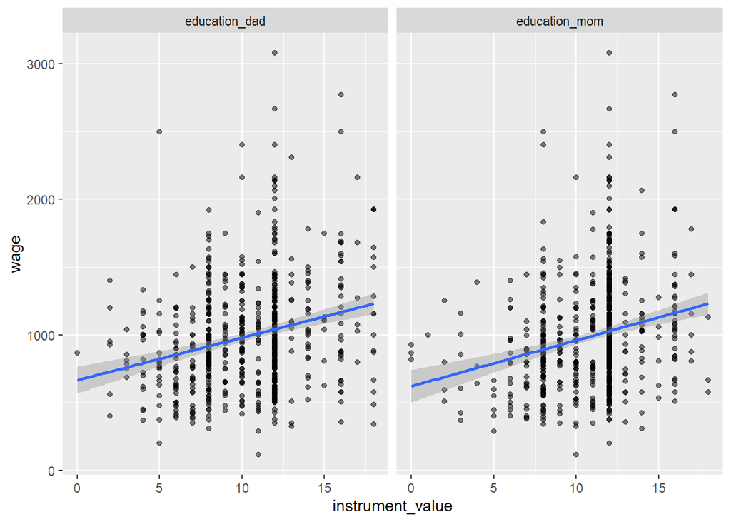

```r
ggplot(ed_real_long, aes(x = instrument_value, y = wage)) +
  geom_point(alpha = 0.5) +
  geom_smooth(method = "lm") +
  facet_wrap(~ instrument)
```

¡Y lo hacemos! Ahora sólo tenemos que argumentar que la única razón por la que existe una relación es que la educación de los padres sólo influye en los salarios a través de la educación. Buena suerte con eso.

#### 5.2.2.3 Exogeneidad

El último paso es demostrar la exogeneidad: que la educación de los padres no está correlacionada con la educación o los salarios. Buena suerte con eso también.

### 5.2.3 Regresión

```r
model_2sls <- iv_robust(wage ~ education | education_dad + education_mom,
                        data = ed_real)
tidy(model_2sls)
```

| term | estimate | std.error | statistic | p.value | conf.low | conf.high | df | outcome |
| --- | --- | --- | --- | --- | --- | --- | --- | --- |
| (Intercept) | -537.7122 | 214.43142 | -2.507618 | 1.239342e-02 | -958.76099 | -116.6633 | 661 | wage |
| education | 111.5614 | 15.90091 | 7.016041 | 5.664276e-12 | 80.33905 | 142.7838 | 661 | wage |

Un año extra de escuela genera unos ingresos adicionales de 111,56 dólares al mes (en dólares de 1980).

### 5.2.4 Compruebe si hay instrumentos débiles

Sin embargo, podemos hacer un par de pruebas más para determinar la resistencia del instrumento . Primero, si incluye el diagnostics = TRUEargumento al ejecutar iv_robust(), puede obtener algunas estadísticas de diagnóstico adicionales.

Volvamos a ejecutar el modelo 2SLS con iv_robustel diagnóstico activado. Para ver los detalles del diagnóstico, no puede usar tidy()(ya que eso solo muestra los coeficientes), por lo que debe usar summary():

```r
model_2sls <- iv_robust(wage ~ education | education_dad + education_mom,
                        data = ed_real, diagnostics = TRUE)
summary(model_2sls)
```

```
##
## Call:
## iv_robust(formula = wage ~ education | education_dad + education_mom,
##     data = ed_real, diagnostics = TRUE)
##
## Standard error type:  HC2
##
## Coefficients:
##             Estimate Std. Error t value  Pr(>|t|) CI Lower CI Upper  DF
## (Intercept)   -537.7      214.4  -2.508 1.239e-02  -958.76   -116.7 661
## education      111.6       15.9   7.016 5.664e-12    80.34    142.8 661
##
## Multiple R-squared:  0.02468 ,   Adjusted R-squared:  0.0232
## F-statistic: 49.22 on 1 and 661 DF,  p-value: 5.664e-12
##
## Diagnostics:
##                  numdf dendf  value  p.value
## Weak instruments     2   660 96.254  < 2e-16 ***
## Wu-Hausman           1   660 16.479 5.51e-05 ***
## Overidentifying      1    NA  0.396    0.529
## ---
## Signif. codes:  0 '***' 0.001 '**' 0.01 '*' 0.05 '.' 0.1 ' ' 1
```

El principal diagnóstico que nos importa aquí es el primero: “Instrumentos débiles”. Esta es una versión un poco más sofisticada de simplemente observar la estadística F de la primera etapa. La hipótesis nula para esta prueba es que los instrumentos que hemos especificado son débiles, por lo que nos gustaría rechazar esa hipótesis nula. Aquí, el valor p es pequeño, por lo que podemos rechazar con seguridad el valor nulo y decir que los instrumentos probablemente no sean débiles. (En general, desea una prueba de instrumentos débiles estadísticamente significativa).

Otro método para comprobar si hay instrumentos débiles es calcular algo llamado conjunto de confianza de Anderson-Rubin, que es esencialmente un intervalo de confianza del 95% para su coeficiente que muestra la estabilidad del coeficiente en función de qué tan débil o fuerte es el instrumento. Esta prueba se inventó alrededor de 1949 y podría decirse que es más sólida que verificar las estadísticas F, pero por alguna razón, ¡nadie la enseña ni la usa realmente! . No está en ninguno de los libros de texto de esta clase y es realmente algo raro. Incluso si busca en Google “instrumentos débiles de prueba de Anderson Rubin”, solo encontrará un montón de notas de clases sofisticadas de econometría.

Además, la mayoría de los paquetes 2SLS R automáticos no proporcionan una manera fácil de realizar esta prueba. El único que encontré está en el paquete AER . Básicamente, cree un modelo 2SLS con AER ivreg()y luego alimente ese modelo a la anderson.rubin.ci()función desde el paquete ivpack . Esto no funciona con los modelos que usted fabrica iv_robust()ni con ninguno de los otros paquetes que funcionan con 2SLS, solo con AER ivreg(). Es una molestia.

La instalación de ivpack ya no es posible porque los mantenedores lo abandonaron y no realizaron las actualizaciones necesarias para mantenerlo en CRAN, por lo que se eliminó en junio de 2022. Eso significa que no puede simplemente ejecutarlo install.packages(“ivpack”).

## 5.3 Educación, salarios y distancia a la universidad (variables de control) (datos reales)

Para este último ejemplo estimaremos el efecto de la educación sobre los salarios utilizando un instrumento diferente: la proximidad geográfica a las universidades. Estos datos provienen del estudio de 1995 de David Card, donde hizo lo mismo, y están disponibles en la biblioteca de Wooldridge como card. Puede encontrar una descripción de todas las variables aquí ; usaremos estos:

**Variables**

- lwage Salario anual (formulario de registro)
- educ Años de educación
- nearc4 Vivir cerca de la universidad (=1) o lejos de la universidad (=0)
- smsa Vivir en área metropolitana (=1) o no (=0)
- exper Años de experiencia
- expersq Años de experiencia (término al cuadrado)
- black Negro (=1), no negro (=0)
- south Vivir en el sur (=1) o no (=0)

```r
card <- read_csv("card.csv")
```

Una vez más, quiere estimar el efecto de la educación sobre los salarios. Pero para eliminar la endogeneidad que surge de la capacidad, utiliza una variable instrumental diferente: la proximidad a la universidad.

También utiliza variables de control para ayudar a explicar la variación adicional en los salarios: smsa66 + exper + expersq + black + south66.

NOTA IMPORTANTE: Cuando incluye controles, cada variable de control debe ir en ambas etapas .

Las únicas cosas de la primera etapa que no se trasladan a la segunda etapa son los instrumentos; observe cómo nearc4 está solo en la primera etapa, ya que es el instrumento, pero no está en la segunda etapa. Los demás controles están todos en ambas etapas.

Por tanto, estima un modelo donde:

Primera etapa:
$$\widehat{\text{educ}} =
\beta_0 + \beta_1\text{nearc4} + \beta_{2-6}\text{Control
variables}$$

Segunda etapa:

$$\text{lwage} = \beta_0 + \beta_1
\widehat{\text{educ}} + \beta_{2-6}\text{Control variables}$$

### 5.3.1 Verificar la validez del instrumento

Card proporciona argumentos para respaldar cada una de las tres características principales de una buena variable instrumental:

- Relevancia : las personas que viven cerca de una universidad de 4 años tienen un acceso más fácil a la educación a costos más bajos (sin costos de desplazamiento ni tiempo ni costos de alojamiento), por lo que tienen mayores incentivos para continuar con la educación.
- Exclusión : La proximidad a una universidad no tiene ningún efecto en sus ingresos anuales, a menos que decida continuar sus estudios debido a la universidad cercana.
- Exogeneidad : la capacidad individual no depende de la proximidad a una universidad. Veamos si estas suposiciones se mantienen:

#### 5.3.1.1 Relevancia

Debe haber una fuerte relación entre el instrumento (distancia a la universidad) y la educación:

```r
first_stage <- lm(educ ~ nearc4 + smsa66 + exper + expersq + black + south66,
                  data = card)
tidy(first_stage)
```

| term | estimate | std.error | statistic | p.value |
| --- | --- | --- | --- | --- |
| (Intercept) | 16.8082084870 | 0.173381027 | 96.9437587 | 0.000000e+00 |
| nearc4 | 0.3337076437 | 0.086971764 | 3.8369653 | 1.271284e-04 |
| smsa66 | 0.2548927174 | 0.084946910 | 3.0006120 | 2.716534e-03 |
| exper | -0.4090050100 | 0.033741985 | -12.1215456 | 4.741904e-33 |
| expersq | 0.0004614893 | 0.001651249 | 0.2794789 | 7.798965e-01 |
| black | -0.9240244401 | 0.093352432 | -9.8982364 | 9.411614e-23 |
| south66 | -0.3475991323 | 0.083162837 | -4.1797412 | 3.001744e-05 |

```r
glance(first_stage)
```

| r.squared | adj.r.squared | sigma | statistic | p.value | df | logLik | AIC | BIC | deviance | df.residual | nobs |
| --- | --- | --- | --- | --- | --- | --- | --- | --- | --- | --- | --- |
| 0.4727217 | 0.4716682 | 1.945753 | 448.714 | 0 | 6 | -6271.104 | 12558.21 | 12606.29 | 11369.22 | 3003 | 3010 |

Según este modelo de primera etapa, nearc4tiene una relación significativa con educ, y el estadístico F conjunto del modelo es 449, que es definitivamente mayor que 10 y 104. Bien. Lo llamaremos relevante.

#### 5.3.1.2 Exclusión

Para que la distancia a la universidad funcione como instrumento y cumpla con la restricción de exclusión, tenemos que demostrar que la distancia a la universidad genera salarios sólo a través de una mayor educación. Piense en otros caminos posibles entre vivir cerca de una universidad y aumentar los salarios; podría haber otros caminos que no pasen por la educación. Buena suerte.

#### 5.3.1.3 Exogeneidad

Para que la distancia a la universidad funcione como un instrumento exógeno, tenemos que demostrar que ninguno de los factores de confusión no observados entre educación e ingresos está relacionado con la distancia. También buena suerte.

### 5.3.2 Estimación 2SLS

Suponiendo que la distancia a la educación sea un instrumento válido (seguro), podemos usarlo en un modelo 2SLS. Recuerde que las variables de control deben ir en ambas etapas, así que especifíquelas en consecuencia en la fórmula del modelo:

```r
model_2sls <- iv_robust(lwage ~ educ + smsa66 + exper + expersq + black + south66 |
                          nearc4 + smsa66 + exper + expersq + black + south66,
                        data = card, diagnostics = TRUE)
tidy(model_2sls)
```

| term | estimate | std.error | statistic | p.value | conf.low | conf.high | df | outcome |
| --- | --- | --- | --- | --- | --- | --- | --- | --- |
| (Intercept) | 3.357231612 | 0.9304151596 | 3.608316 | 3.132198e-04 | 1.532916120 | 5.1815471040 | 3003 | lwage |
| educ | 0.157217725 | 0.0548065864 | 2.868592 | 4.151811e-03 | 0.049755477 | 0.2646799730 | 3003 | lwage |
| smsa66 | 0.080966557 | 0.0268577012 | 3.014650 | 2.594285e-03 | 0.028305205 | 0.1336279094 | 3003 | lwage |
| exper | 0.118351660 | 0.0236492932 | 5.004448 | 5.925013e-07 | 0.071981207 | 0.1647221123 | 3003 | lwage |
| expersq | -0.002414645 | 0.0003661153 | -6.595311 | 4.995591e-11 | -0.003132507 | -0.0016967824 | 3003 | lwage |
| black | -0.103583362 | 0.0524509508 | -1.974861 | 4.837533e-02 | -0.206426787 | -0.0007399363 | 3003 | lwage |
| south66 | -0.063713365 | 0.0279787020 | -2.277209 | 2.284375e-02 | -0.118572724 | -0.0088540054 | 3003 | lwage |

Según el coeficiente de educ, un año de educación provoca un aumento del 15,7% en los salarios anuales, en promedio.

¿Es eso una mejora con respecto a un modelo ingenuo en el que no tomamos en cuenta nada de la endogeneidad?

```r
model_naive <- lm(lwage ~ educ + smsa66 + exper + expersq + black + south66,
                  data = card)
tidy(model_naive)
```

| term | estimate | std.error | statistic | p.value |
| --- | --- | --- | --- | --- |
| (Intercept) | 4.731399280 | 0.0686437095 | 68.926917 | 0.000000e+00 |
| educ | 0.076231337 | 0.0035523388 | 21.459478 | 3.680155e-95 |
| smsa66 | 0.112738574 | 0.0150959283 | 7.468145 | 1.060049e-13 |
| exper | 0.085225629 | 0.0067429426 | 12.639234 | 1.024827e-35 |
| expersq | -0.002380656 | 0.0003222269 | -7.388137 | 1.919604e-13 |
| black | -0.176986156 | 0.0184776259 | -9.578403 | 1.988178e-21 |
| south66 | -0.096010711 | 0.0160809309 | -5.970470 | 2.642872e-09 |

¡Sí! Sin eliminar la endogeneidad de la educación, un año adicional de educación sólo se asocia con un aumento del 7,6% en los salarios anuales, en promedio.